# Dietary intake, Nutritional status, and Health outcomes among Vegan, Vegetarian and Omnivore families: results from the observational study

- Show All Code
- Hide All Code
- View Source

Statistical report - mixed models summary

**Authors and affiliations**

Marina Heniková<sup>1,2</sup>, Anna Ouřadová<sup>1</sup>, Eliška Selinger<sup>1,3</sup>, Filip Tichanek<sup>4</sup>, Petra Polakovičová<sup>4</sup>, Dana Hrnčířová<sup>2</sup>, Pavel Dlouhý<sup>2</sup>, Martin Světnička<sup>5</sup>, Eva El-Lababidi<sup>5</sup>, Jana Potočková<sup>1</sup>, Tilman Kühn<sup>6</sup>, Monika Cahová<sup>4</sup>, Jan Gojda<sup>1</sup>

<sup>1</sup> Department of Internal Medicine, Kralovske Vinohrady University Hospital and Third Faculty of Medicine, Charles University, Prague, Czech Republic.  
<sup>2</sup> Department of Hygiene, Third Faculty of Medicine, Charles University, Prague, Czech Republic.  
<sup>3</sup> National Health Institute, Prague, Czech Republic.  
<sup>4</sup> Institute for Clinical and Experimental Medicine, Prague, Czech Republic.  
<sup>5</sup> Department of Pediatrics, Kralovske Vinohrady University Hospital and Third Faculty of Medicine, Charles University, Prague, Czech Republic.  
<sup>6</sup> Department of Epidemiology, MedUni, Vienna, Austria.

This is a statistical report of the study currenlty *under review* in the [*Communications Medicine*](https://www.nature.com/commsmed) journal.

Original [GitHub repository](https://github.com/filip-tichanek/kompas_clinical): https://github.com/filip-tichanek/kompas_clinical

Statistical **reports** can be found on the [reports hub](https://filip-tichanek.github.io/kompas_clinical/).

Data analysis is described in detail in the [statistical methods](https://filip-tichanek.github.io/kompas_clinical/html/368_G_Methods.html) report.

# 1 Introduction

This project is designed to evaluate and compare clinical outcomes across three distinct dietary strategy groups:

- Vegans
- Vegetarians
- Omnivores

The dataset includes both adults and children, with data clustered within families.

## 1.1 Main Questions

The study addresses the following key questions:

Q1. Do clinical outcomes vary significantly across different diet strategies?

Q2. Beyond diet group, which factors (e.g., sex, age, breastfeeding status for children, or supplementation when applicable) most strongly influence clinical outcomes? How correlated (“clustered”) are these characteristics within the same family?

Q3. Could the clinical characteristics effectively discriminate between different diet groups?

## 1.2 Statistical Methods

For full methodological details, see [this report](https://filip-tichanek.github.io/kompas_clinical/html/368_G_Methods.html). In brief:

- **Robust linear mixed-effects models (rLME)** were used to estimate adjusted differences between diet groups (Q1) and assess the importance of other variables (Q2), including how much clinical characteristics tend to cluster within families. Covariates included age, sex, breastfeeding status for children, and relevant supplementation factors where applicable.
- **Elastic net logistic regression** was employed to answer Q3, evaluating whether clinical characteristics provide a strong overall signal distinguishing between diet groups, incorporating a predictive perspective.

All analyses were conducted separately for adults and children.

# 2 Robust linear-mixed-effects models

**Open code**

```r
source('r/368_initiation.R')
```

## 2.1 Children

### 2.1.1 Diet effects

#### 2.1.1.1 Unstandardized effects

**Open code**

```r
diet_child_all <- read.xlsx("gitignore/data/diet_child_all_mixeff.xlsx") %>%
  mutate(outcome = clean_outcome_names(outcome)) %>%
  mutate(outcome = case_when(
    outcome == "FOLAT" ~ "FOLATE",
    outcome == "VKFE" ~ "TIBC",
    outcome == "Cros" ~ "CTX",
    outcome == "log2_Cros" ~ "log2_CTX",
    outcome == "VIT_AKTB12" ~ "HOLOTC",
    outcome == "log2_VIT_AKTB12" ~ "log2_HOLOTC",
    outcome == "log2_Ur_Ca" ~ "log2_uCa",
    outcome == "log2_Ca_per_Krea" ~ "log2_uCCR",
    outcome == "log2_I_per_Krea" ~ "log2_uICR",
    outcome == "P_per_Krea" ~ "uPCR",
    outcome == "log2_P_per_Krea" ~ "log2_uPCR",
    TRUE ~ outcome
  ))

diet_child_all2 <- diet_child_all %>%
  mutate(across(.cols = c(VN_OM_diff, VG_OM_diff, VN_VG_diff), ~ round(.x, 2)))


kableExtra::kable(diet_child_all2,
  caption = "Differences in clinical outcomes (`outcome`) between diet groups in children, estimated using robust linear mixed-effects models. For each outcome, the table reports the estimated difference (`[...]_diff`), raw p-value (`[...]_P`), and FDR-corrected p-value (`[...]_P_adj`) for multiple comparisons. Comparisons include (A) vegans vs. omnivores (`VN_OM`), (B) vegetarians vs. omnivores (`VG_OM`), and (C) vegans vs. vegetarians (`VN_VG`)."
) %>%
  kable_styling("striped", full_width = T) %>%
  add_header_above(c(
    " " = 2, "(A) VN vs OM" = 3,
    "(B) VG vs OM" = 3, "(C) VN vs VG" = 3
  )) %>%
  column_spec(1, width_min = "1.5in")
```

Differences in clinical outcomes (`outcome`) between diet groups in children, estimated using robust linear mixed-effects models. For each outcome, the table reports the estimated difference (`[...]_diff`), raw p-value (`[...]_P`), and FDR-corrected p-value (`[...]_P_adj`) for multiple comparisons. Comparisons include (A) vegans vs. omnivores (`VN_OM`), (B) vegetarians vs. omnivores (`VG_OM`), and (C) vegans vs. vegetarians (`VN_VG`).

| outcome | estimand | (A) VN vs OM VN_OM_diff | (A) VN vs OM VN_OM_P | (A) VN vs OM VN_OM_P_adj | (B) VG vs OM VG_OM_diff | (B) VG vs OM VG_OM_P | (B) VG vs OM VG_OM_P_adj | (C) VN vs VG VN_VG_diff | (C) VN vs VG VN_VG_P | (C) VN vs VG VN_VG_P_adj |
| --- | --- | --- | --- | --- | --- | --- | --- | --- | --- | --- |
| MASS_Perc | mean | -9.23 | 0.1368814 | 0.3220738 | -3.60 | 0.6140181 | 0.9863118 | -5.63 | 0.3798854 | 0.7436615 |
| HEIGHT_Perc | mean | -7.97 | 0.2305660 | 0.3842767 | 0.86 | 0.9114004 | 0.9863118 | -8.83 | 0.1967938 | 0.6361680 |
| BMI_PERC | mean | -2.32 | 0.7047050 | 0.8290647 | -2.79 | 0.6940089 | 0.9863118 | 0.47 | 0.9403351 | 0.9403351 |
| M_per_H_PERC | mean | -3.17 | 0.5747725 | 0.7184656 | -3.66 | 0.5716597 | 0.9863118 | 0.49 | 0.9331269 | 0.9403351 |
| GLY | mean | 0.01 | 0.9195424 | 0.9566299 | 0.05 | 0.6481973 | 0.9863118 | -0.04 | 0.6997053 | 0.8672515 |
| TC | mean | -0.32 | 0.0370824 | 0.1236081 | -0.18 | 0.3083592 | 0.9856067 | -0.14 | 0.4090138 | 0.7436615 |
| HDL | mean | -0.01 | 0.8826851 | 0.9542542 | -0.06 | 0.4997270 | 0.9863118 | 0.05 | 0.5453018 | 0.8078545 |
| LDL | mean | -0.25 | 0.0288423 | 0.1176745 | 0.08 | 0.5545440 | 0.9863118 | -0.33 | 0.0089436 | 0.0715485 |
| log2_TG | mean | -0.01 | 0.9566299 | 0.9566299 | -0.31 | 0.0884329 | 0.9092226 | 0.30 | 0.0712944 | 0.3664534 |
| Ca | mean | -0.02 | 0.4939300 | 0.6585733 | 0.01 | 0.7974114 | 0.9863118 | -0.02 | 0.3579991 | 0.7436615 |
| P | mean | -0.03 | 0.4692479 | 0.6472385 | 0.00 | 0.9409113 | 0.9863118 | -0.03 | 0.4533815 | 0.7487340 |
| Mg | mean | 0.03 | 0.0303454 | 0.1176745 | 0.03 | 0.0909223 | 0.9092226 | 0.00 | 0.8451016 | 0.9099736 |
| log2_Se | mean | -0.17 | 0.1938190 | 0.3691790 | -0.02 | 0.9174542 | 0.9863118 | -0.15 | 0.2765187 | 0.6563408 |
| log2_Zn | mean | -0.13 | 0.0481466 | 0.1374279 | -0.08 | 0.2842636 | 0.9856067 | -0.05 | 0.5226594 | 0.8040914 |
| FE | mean | 1.81 | 0.1888387 | 0.3691790 | -0.77 | 0.6250206 | 0.9863118 | 2.58 | 0.0874415 | 0.3664534 |
| TIBC | mean | -4.02 | 0.0323605 | 0.1176745 | -1.47 | 0.4931661 | 0.9863118 | -2.54 | 0.2160265 | 0.6361680 |
| log2_FERR | mean | -0.25 | 0.1295455 | 0.3220738 | -0.19 | 0.3142560 | 0.9856067 | -0.06 | 0.7459186 | 0.8775513 |
| TRF | mean | -0.17 | 0.0242801 | 0.1176745 | -0.07 | 0.4072626 | 0.9863118 | -0.10 | 0.2390322 | 0.6374193 |
| SATTRF | mean | 3.82 | 0.0515355 | 0.1374279 | -0.03 | 0.9885952 | 0.9885952 | 3.85 | 0.0738694 | 0.3664534 |
| log2_TRFINDEX | mean | 0.03 | 0.6950900 | 0.8290647 | 0.08 | 0.4471824 | 0.9863118 | -0.04 | 0.6593668 | 0.8578668 |
| log2_STRF | mean | -0.03 | 0.5724161 | 0.7184656 | 0.01 | 0.8399455 | 0.9863118 | -0.04 | 0.4679587 | 0.7487340 |
| HGB | mean | -0.44 | 0.8101738 | 0.9238143 | 1.14 | 0.5912508 | 0.9863118 | -1.58 | 0.4337484 | 0.7487340 |
| MCV | mean | 2.97 | 0.0001520 | 0.0020269 | -0.13 | 0.8923264 | 0.9863118 | 3.10 | 0.0002773 | 0.0038755 |
| PTH | mean | 0.38 | 0.2039043 | 0.3707351 | -0.02 | 0.9616540 | 0.9863118 | 0.39 | 0.2226588 | 0.6361680 |
| log2_CTX | mean | 0.06 | 0.4638317 | 0.6472385 | 0.08 | 0.3449623 | 0.9856067 | -0.03 | 0.7154825 | 0.8672515 |
| P1NP | mean | 41.88 | 0.2895625 | 0.4454808 | 63.17 | 0.1819924 | 0.9099621 | -21.29 | 0.6218130 | 0.8576731 |
| log2_UI | mean | -0.79 | 0.0005746 | 0.0057464 | -0.37 | 0.1371521 | 0.9099621 | -0.41 | 0.0725949 | 0.3664534 |
| UREA | mean | -0.55 | 0.0104269 | 0.0595822 | -0.17 | 0.4881839 | 0.9863118 | -0.38 | 0.1075133 | 0.3909573 |
| log2_CREA | mean | -0.11 | 0.0416995 | 0.1283063 | -0.06 | 0.3350035 | 0.9856067 | -0.05 | 0.4003741 | 0.7436615 |
| UA | mean | -2.38 | 0.8314328 | 0.9238143 | -4.94 | 0.7086404 | 0.9863118 | 2.56 | 0.8310370 | 0.9099736 |
| log2_HOLOTC | mean | 0.30 | 0.1537853 | 0.3417452 | -0.31 | 0.1449102 | 0.9099621 | 0.61 | 0.0002554 | 0.0038755 |
| log2_HCY | mean | -0.14 | 0.2222796 | 0.3842767 | 0.02 | 0.9025532 | 0.9863118 | -0.16 | 0.0916134 | 0.3664534 |
| log2_MMA | mean | -0.58 | 0.0076679 | 0.0511195 | -0.07 | 0.7609094 | 0.9863118 | -0.51 | 0.0021082 | 0.0210824 |
| log2_VIT_D | mean | 0.28 | 0.0064921 | 0.0511195 | 0.26 | 0.0328104 | 0.6562074 | 0.02 | 0.8644749 | 0.9099736 |
| FOLATE | mean | 4.30 | 0.0000071 | 0.0001412 | 4.81 | 0.0000182 | 0.0007284 | -0.51 | 0.6198255 | 0.8576731 |
| log2_IGF1 | mean | -0.16 | 0.2883477 | 0.4454808 | 0.01 | 0.9512789 | 0.9863118 | -0.17 | 0.3024966 | 0.6722147 |
| log2_uCa | mean | -0.42 | 0.3236212 | 0.4794388 | 0.04 | 0.9403988 | 0.9863118 | -0.46 | 0.2789448 | 0.6563408 |
| log2_uCCR | mean | 0.02 | 0.9484718 | 0.9566299 | 0.19 | 0.6604621 | 0.9863118 | -0.17 | 0.6648468 | 0.8578668 |
| log2_uICR | mean | -0.38 | 0.1787353 | 0.3691790 | -0.31 | 0.3233064 | 0.9856067 | -0.07 | 0.7991710 | 0.9099736 |
| uPCR | mean | -2.12 | 0.0000002 | 0.0000088 | -0.63 | 0.1606090 | 0.9099621 | -1.48 | 0.0002907 | 0.0038755 |

#### 2.1.1.2 Standardized effects by 1SD

**Open code**

```r
meds <- diet_child_all %>% filter(estimand == "mean")

ids <- nrow(meds)
sds <- vector("double", ids)
sds
##  [1] 0 0 0 0 0 0 0 0 0 0 0 0 0 0 0 0 0 0 0 0 0 0 0 0 0 0 0 0 0 0 0 0 0 0 0 0 0 0
## [39] 0 0

before_outcome_col <- which(colnames(dat_child_all) == 'aMASS_Perc')-1

sds <- vector("double", ids)

for(i in 1:ids){
  sds[i] <- ifelse(grepl("log2", diet_child_all[(i), 'outcome']),
                   sd(log2(dat_child_all[,(i + before_outcome_col)]), na.rm = TRUE),
                   sd(dat_child_all[,(i + before_outcome_col)], na.rm = TRUE))
}


diet_child_all_Z <- diet_child_all %>%
  mutate(SD = sds) %>%
  mutate(
    VN_OM_diff = VN_OM_diff/SD,
    VG_OM_diff = VG_OM_diff/SD,
    VN_VG_diff = VN_VG_diff/SD) %>%
  select(-c(SD)) %>%
  mutate(across(.cols = c(VG_OM_diff, VN_OM_diff, VN_VG_diff), ~ round(.x, 2)))


kbl(diet_child_all_Z, caption =
      "Standardized differences in clinical outcomes (`outcome`) between diet groups in children, estimated using robust linear mixed-effects models. For each outcome, the table reports the estimated difference (`[...]_diff`), raw p-value (`[...]_P`), and FDR-corrected p-value (`[...]_P_adj`) for multiple comparisons. Comparisons include (A) vegans vs. omnivores (`VN_OM`), (B) vegetarians vs. omnivores (`VG_OM`), and (C) vegans vs. vegetarians (`VN_VG`).") %>%
  kable_styling("striped",full_width = T) %>%
  add_header_above(c(" " = 2, "(A) VN vs OM" = 3,
                     "(B) VG vs OM" = 3, "(C) VN vs VG" =3)) %>%
  column_spec(1, width_min = '1.5in')
```

Standardized differences in clinical outcomes (`outcome`) between diet groups in children, estimated using robust linear mixed-effects models. For each outcome, the table reports the estimated difference (`[...]_diff`), raw p-value (`[...]_P`), and FDR-corrected p-value (`[...]_P_adj`) for multiple comparisons. Comparisons include (A) vegans vs. omnivores (`VN_OM`), (B) vegetarians vs. omnivores (`VG_OM`), and (C) vegans vs. vegetarians (`VN_VG`).

| outcome | estimand | (A) VN vs OM VN_OM_diff | (A) VN vs OM VN_OM_P | (A) VN vs OM VN_OM_P_adj | (B) VG vs OM VG_OM_diff | (B) VG vs OM VG_OM_P | (B) VG vs OM VG_OM_P_adj | (C) VN vs VG VN_VG_diff | (C) VN vs VG VN_VG_P | (C) VN vs VG VN_VG_P_adj |
| --- | --- | --- | --- | --- | --- | --- | --- | --- | --- | --- |
| MASS_Perc | mean | -0.32 | 0.1368814 | 0.3220738 | -0.12 | 0.6140181 | 0.9863118 | -0.20 | 0.3798854 | 0.7436615 |
| HEIGHT_Perc | mean | -0.29 | 0.2305660 | 0.3842767 | 0.03 | 0.9114004 | 0.9863118 | -0.32 | 0.1967938 | 0.6361680 |
| BMI_PERC | mean | -0.09 | 0.7047050 | 0.8290647 | -0.11 | 0.6940089 | 0.9863118 | 0.02 | 0.9403351 | 0.9403351 |
| M_per_H_PERC | mean | -0.13 | 0.5747725 | 0.7184656 | -0.15 | 0.5716597 | 0.9863118 | 0.02 | 0.9331269 | 0.9403351 |
| GLY | mean | 0.02 | 0.9195424 | 0.9566299 | 0.09 | 0.6481973 | 0.9863118 | -0.07 | 0.6997053 | 0.8672515 |
| TC | mean | -0.49 | 0.0370824 | 0.1236081 | -0.28 | 0.3083592 | 0.9856067 | -0.21 | 0.4090138 | 0.7436615 |
| HDL | mean | -0.04 | 0.8826851 | 0.9542542 | -0.19 | 0.4997270 | 0.9863118 | 0.15 | 0.5453018 | 0.8078545 |
| LDL | mean | -0.45 | 0.0288423 | 0.1176745 | 0.14 | 0.5545440 | 0.9863118 | -0.58 | 0.0089436 | 0.0715485 |
| log2_TG | mean | -0.01 | 0.9566299 | 0.9566299 | -0.43 | 0.0884329 | 0.9092226 | 0.42 | 0.0712944 | 0.3664534 |
| Ca | mean | -0.14 | 0.4939300 | 0.6585733 | 0.06 | 0.7974114 | 0.9863118 | -0.21 | 0.3579991 | 0.7436615 |
| P | mean | -0.16 | 0.4692479 | 0.6472385 | 0.02 | 0.9409113 | 0.9863118 | -0.18 | 0.4533815 | 0.7487340 |
| Mg | mean | 0.40 | 0.0303454 | 0.1176745 | 0.36 | 0.0909223 | 0.9092226 | 0.04 | 0.8451016 | 0.9099736 |
| log2_Se | mean | -0.33 | 0.1938190 | 0.3691790 | -0.03 | 0.9174542 | 0.9863118 | -0.30 | 0.2765187 | 0.6563408 |
| log2_Zn | mean | -0.43 | 0.0481466 | 0.1374279 | -0.28 | 0.2842636 | 0.9856067 | -0.16 | 0.5226594 | 0.8040914 |
| FE | mean | 0.26 | 0.1888387 | 0.3691790 | -0.11 | 0.6250206 | 0.9863118 | 0.37 | 0.0874415 | 0.3664534 |
| TIBC | mean | -0.44 | 0.0323605 | 0.1176745 | -0.16 | 0.4931661 | 0.9863118 | -0.28 | 0.2160265 | 0.6361680 |
| log2_FERR | mean | -0.28 | 0.1295455 | 0.3220738 | -0.22 | 0.3142560 | 0.9856067 | -0.07 | 0.7459186 | 0.8775513 |
| TRF | mean | -0.47 | 0.0242801 | 0.1176745 | -0.20 | 0.4072626 | 0.9863118 | -0.27 | 0.2390322 | 0.6374193 |
| SATTRF | mean | 0.39 | 0.0515355 | 0.1374279 | 0.00 | 0.9885952 | 0.9885952 | 0.39 | 0.0738694 | 0.3664534 |
| log2_TRFINDEX | mean | 0.06 | 0.6950900 | 0.8290647 | 0.14 | 0.4471824 | 0.9863118 | -0.08 | 0.6593668 | 0.8578668 |
| log2_STRF | mean | -0.11 | 0.5724161 | 0.7184656 | 0.04 | 0.8399455 | 0.9863118 | -0.15 | 0.4679587 | 0.7487340 |
| HGB | mean | -0.05 | 0.8101738 | 0.9238143 | 0.12 | 0.5912508 | 0.9863118 | -0.17 | 0.4337484 | 0.7487340 |
| MCV | mean | 0.78 | 0.0001520 | 0.0020269 | -0.03 | 0.8923264 | 0.9863118 | 0.81 | 0.0002773 | 0.0038755 |
| PTH | mean | 0.30 | 0.2039043 | 0.3707351 | -0.01 | 0.9616540 | 0.9863118 | 0.31 | 0.2226588 | 0.6361680 |
| log2_CTX | mean | 0.15 | 0.4638317 | 0.6472385 | 0.24 | 0.3449623 | 0.9856067 | -0.08 | 0.7154825 | 0.8672515 |
| P1NP | mean | 0.14 | 0.2895625 | 0.4454808 | 0.21 | 0.1819924 | 0.9099621 | -0.07 | 0.6218130 | 0.8576731 |
| log2_UI | mean | -0.63 | 0.0005746 | 0.0057464 | -0.30 | 0.1371521 | 0.9099621 | -0.33 | 0.0725949 | 0.3664534 |
| UREA | mean | -0.44 | 0.0104269 | 0.0595822 | -0.14 | 0.4881839 | 0.9863118 | -0.30 | 0.1075133 | 0.3909573 |
| log2_CREA | mean | -0.27 | 0.0416995 | 0.1283063 | -0.15 | 0.3350035 | 0.9856067 | -0.12 | 0.4003741 | 0.7436615 |
| UA | mean | -0.05 | 0.8314328 | 0.9238143 | -0.10 | 0.7086404 | 0.9863118 | 0.05 | 0.8310370 | 0.9099736 |
| log2_HOLOTC | mean | 0.37 | 0.1537853 | 0.3417452 | -0.38 | 0.1449102 | 0.9099621 | 0.75 | 0.0002554 | 0.0038755 |
| log2_HCY | mean | -0.32 | 0.2222796 | 0.3842767 | 0.03 | 0.9025532 | 0.9863118 | -0.36 | 0.0916134 | 0.3664534 |
| log2_MMA | mean | -0.64 | 0.0076679 | 0.0511195 | -0.07 | 0.7609094 | 0.9863118 | -0.56 | 0.0021082 | 0.0210824 |
| log2_VIT_D | mean | 0.61 | 0.0064921 | 0.0511195 | 0.57 | 0.0328104 | 0.6562074 | 0.04 | 0.8644749 | 0.9099736 |
| FOLATE | mean | 0.92 | 0.0000071 | 0.0001412 | 1.03 | 0.0000182 | 0.0007284 | -0.11 | 0.6198255 | 0.8576731 |
| log2_IGF1 | mean | -0.19 | 0.2883477 | 0.4454808 | 0.01 | 0.9512789 | 0.9863118 | -0.20 | 0.3024966 | 0.6722147 |
| log2_uCa | mean | -0.29 | 0.3236212 | 0.4794388 | 0.02 | 0.9403988 | 0.9863118 | -0.31 | 0.2789448 | 0.6563408 |
| log2_uCCR | mean | 0.02 | 0.9484718 | 0.9566299 | 0.13 | 0.6604621 | 0.9863118 | -0.11 | 0.6648468 | 0.8578668 |
| log2_uICR | mean | -0.29 | 0.1787353 | 0.3691790 | -0.24 | 0.3233064 | 0.9856067 | -0.06 | 0.7991710 | 0.9099736 |
| uPCR | mean | -0.99 | 0.0000002 | 0.0000088 | -0.30 | 0.1606090 | 0.9099621 | -0.70 | 0.0002907 | 0.0038755 |

#### 2.1.1.3 Vulcano plots

VN vs OM

**Open code**

```r
color_map <- c(
  "OM+" = rgb(213/255, 94/255, 0),
  "VN+" = rgb(0, 158/255, 75/255),
  "VG+" = rgb(0, 95/255, 195/255),
  "P>0.05" = "grey50"
)

plotac <- "fig19"

path <- paste0("gitignore/figures/", plotac, ".rds")

if (file.exists(path) == FALSE) {
  assign(plotac, diet_child_all_Z %>%
    filter(estimand != "log(OR)") %>%
    mutate(
      pv_adj = VN_OM_P_adj,
      pv_raw = VN_OM_P,
      b_coe = VN_OM_diff
    ) %>%
    mutate(pv_raw = if_else(pv_raw < 1e-5, 1e-5, pv_raw)) %>%
    mutate(
      m_ylab = -log10(pv_raw),
      m_xlab = b_coe,
      rescat = if_else(
        pv_raw >= 0.05,
        "P>0.05",
        if_else(
          b_coe > 0,
          "VN+",
          "OM+"
        )
      )
    ) %>%
    mutate(
      rescat = factor(rescat,
        levels = c("OM+", "VN+", "P>0.05")
      ),
      meta_labels = if_else(pv_raw < 0.05, outcome, "")
    ) %>%
    ggplot(aes(
      x = b_coe,
      y = m_ylab,
      color = rescat,
      alpha = rescat,
      label = meta_labels
    )) +
    geom_point(size = 2, shape = 16, alpha = 0.6) +
    geom_text_repel(
      aes(
        x = m_xlab,
        y = m_ylab
      ),
      show.legend = FALSE,
      alpha = 1,
      box.padding = 0.3,
      size = 3.1,
      seed = 17
    ) +
    labs(x = "Standardized difference", y = "-log10 (P-value)") +
    scale_color_manual(values = color_map, name = "") +
    ggtitle("VN vs. OM, all children") +
    theme(
      legend.text = element_text(size = 11),
      axis.title = element_text(size = 12)
    ) +
    coord_cartesian(
      ylim = c(0, 5),
      xlim = c(-1.7, 1.7)
    ))

  saveRDS(get(plotac), file = path)
} else {
  assign(plotac, readRDS(path))
}
```

VG vs OM

**Open code**

```r
plotac <- "fig20"

path <- paste0("gitignore/figures/", plotac, ".rds")

if (file.exists(path) == FALSE) {
  assign(plotac, diet_child_all_Z %>%
    filter(estimand != "log(OR)") %>%
    mutate(VG_OM_P = if_else(VG_OM_P < 1e-5, 1e-5, VG_OM_P)) %>%
    mutate(
      pv_adj = VG_OM_P_adj,
      pv_raw = VG_OM_P,
      b_coe = VG_OM_diff
    ) %>%
    mutate(pv_raw = if_else(pv_raw < 1e-5, 1e-5, pv_raw)) %>%
    mutate(
      m_ylab = -log10(pv_raw),
      m_xlab = b_coe,
      rescat = if_else(
        pv_raw >= 0.05,
        "P>0.05",
        if_else(
          b_coe > 0,
          "VG+",
          "OM+"
        )
      )
    ) %>%
    mutate(
      rescat = factor(rescat,
        levels = c("OM+", "VG+", "P>0.05")
      ),
      meta_labels = if_else(pv_raw < 0.05, outcome, "")
    ) %>%
    ggplot(aes(
      x = b_coe,
      y = m_ylab,
      color = rescat,
      alpha = rescat,
      label = meta_labels
    )) +
    geom_point(size = 2, shape = 16, alpha = 0.6) +
    geom_text_repel(
      aes(
        x = m_xlab,
        y = m_ylab
      ),
      show.legend = FALSE,
      alpha = 1,
      box.padding = 0.3,
      size = 3.1,
      seed = 17
    ) +
    labs(x = "Standardized difference", y = "-log10 (P-value)") +
    scale_color_manual(values = color_map, name = "") +
    ggtitle("VG vs. OM, all children") +
    theme(
      legend.text = element_text(size = 11),
      axis.title = element_text(size = 12)
    ) +
    coord_cartesian(
      ylim = c(0, 5),
      xlim = c(-1.7, 1.7)
    ))

  saveRDS(get(plotac), file = path)
} else {
  assign(plotac, readRDS(path))
}
```

VN vs VG

**Open code**

```r
plotac <- "fig21"

path <- paste0("gitignore/figures/", plotac, ".rds")

if (file.exists(path) == FALSE) {
  assign(plotac, diet_child_all_Z %>%
    filter(estimand != "log(OR)") %>%

    mutate(
      pv_adj = VN_VG_P_adj,
      pv_raw = VN_VG_P,
      b_coe = VN_VG_diff
    ) %>%
    mutate(pv_raw = if_else(pv_raw < 1e-5, 1e-5, pv_raw)) %>%
    mutate(
      m_ylab = -log10(pv_raw),
      m_xlab = b_coe,
      rescat = if_else(
        pv_raw >= 0.05,
        "P>0.05",
        if_else(
          b_coe > 0,
          "VN+",
          "VG+"
        )
      )
    ) %>%
    mutate(
      rescat = factor(rescat,
        levels = c(
          "VG+",
          "VN+",
          "P>0.05"
        )
      ),
      meta_labels = if_else(pv_raw < 0.05, outcome, "")
    ) %>%
    ggplot(aes(
      x = b_coe,
      y = m_ylab,
      color = rescat,
      alpha = rescat,
      label = meta_labels
    )) +
    geom_point(size = 2, shape = 16, alpha = 0.6) +
    geom_text_repel(
      aes(
        x = m_xlab,
        y = m_ylab
      ),
      show.legend = FALSE,
      alpha = 1,
      box.padding = 0.5,
      size = 3.1,
      seed = 16
    ) +
    labs(
      x = "Standardized difference",
      y = "-log10 (P-value)"
    ) +
    scale_color_manual(values = color_map, name = "") +
    ggtitle("VN vs VG, all children") +
    theme(
      legend.text = element_text(size = 11),
      axis.title = element_text(size = 12)
    ) +
    coord_cartesian(
      ylim = c(0, 5),
      xlim = c(-1.7, 1.7)
    ))

  saveRDS(get(plotac), file = path)
} else {
  assign(plotac, readRDS(path))
}
```

### 2.1.2 Covariates importance

#### 2.1.2.1 Table

**Open code**

```r
AIC_child_all <- read.xlsx("gitignore/data/AIC_child_all_mixeff.xlsx") %>%
  mutate(across(where(is.numeric), ~ round(., 1)),
    outcome = clean_outcome_names(outcome)
  ) %>%
  rename(
    SEX = aSEX,
    BREASTFEED = Breast_Feed,
    `OTHER COV` = other_cov,
    FAMILY = family,
    DIET = diet,
    AGE = log2_age
  ) %>%
  mutate(outcome = case_when(
    outcome == "FOLAT" ~ "FOLATE",
    outcome == "VKFE" ~ "TIBC",
    outcome == "Cros" ~ "CTX",
    outcome == "log2_Cros" ~ "log2_CTX",
    outcome == "VIT_AKTB12" ~ "HOLOTC",
    outcome == "log2_VIT_AKTB12" ~ "log2_HOLOTC",

    outcome == 'log2_aUr_Ca' ~ 'log2_uCa',
    outcome == 'log2_Ca_per_Krea' ~ 'log2_uCCR',
    outcome == 'log2_I_per_Krea' ~ 'log2_uICR',
    outcome == 'P_per_Krea' ~ 'uPCR',
    outcome == 'log2_P_per_Krea' ~ 'log2_uPCR',

    TRUE ~ outcome
  ))

kbl(AIC_child_all,
  caption =
    "Change of the Akaike Information Criterion (AIC) after addition of a given variable to mixed effects models for children. The magnitude of the AIC change indicates the impact on out-of-sample predictive accuracy, with more negative values reflecting greater importance of the variable."
) %>%
  kable_styling("striped", full_width = T) %>%
  column_spec(1, width_min = "1.5in")
```

Change of the Akaike Information Criterion (AIC) after addition of a given variable to mixed effects models for children. The magnitude of the AIC change indicates the impact on out-of-sample predictive accuracy, with more negative values reflecting greater importance of the variable.

| outcome | estimand | AGE | SEX | BREASTFEED | OTHER COV | DIET | FAMILY |
| --- | --- | --- | --- | --- | --- | --- | --- |
| MASS_Perc | mean | NA | 1.9 | 2.9 | -25.4 | 1.8 | -4.8 |
| HEIGHT_Perc | mean | NA | 2.3 | 5.1 | -18.5 | 1.2 | -9.2 |
| BMI_PERC | mean | NA | 0.8 | 4.4 | -9.6 | 4.2 | -2.6 |
| M_per_H_PERC | mean | NA | 1.5 | 4.6 | -9.4 | 4.1 | -1.1 |
| GLY | mean | 2.3 | 2.0 | 5.7 | NA | 4.4 | 1.7 |
| TC | mean | 1.8 | 2.3 | 3.2 | NA | -0.6 | -1.1 |
| HDL | mean | -5.9 | -1.4 | 3.5 | NA | 3.8 | -6.7 |
| LDL | mean | 2.3 | 1.9 | 2.6 | NA | -3.1 | -1.3 |
| log2_TG | mean | -2.4 | -0.8 | 3.6 | NA | 0.7 | -5.4 |
| Ca | mean | -25.0 | -1.0 | 5.3 | NA | 3.8 | -4.1 |
| P | mean | -33.7 | 2.3 | 3.3 | NA | 3.7 | -5.0 |
| Mg | mean | -0.4 | 1.5 | 0.2 | 1.5 | 0.7 | 0.1 |
| log2_Se | mean | 2.3 | 2.3 | 2.3 | -2.4 | 2.8 | -12.3 |
| log2_Zn | mean | 0.8 | 2.3 | 6.3 | 2.2 | 2.2 | -1.9 |
| FE | mean | -6.8 | 2.0 | 6.3 | 2.3 | 2.6 | -1.8 |
| TIBC | mean | 0.4 | 2.1 | -2.6 | -2.5 | 0.5 | -4.2 |
| log2_FERR | mean | -13.3 | 1.7 | -12.1 | -1.3 | 2.5 | -1.9 |
| TRF | mean | 0.8 | 1.8 | -3.0 | -2.9 | 0.0 | -3.4 |
| SATTRF | mean | -7.5 | 1.9 | 5.0 | 1.7 | 1.3 | -1.1 |
| log2_TRFINDEX | mean | -19.8 | 1.2 | -12.1 | -2.5 | 4.2 | -0.2 |
| log2_STRF | mean | -18.3 | 1.8 | -7.7 | -3.4 | 3.8 | -0.3 |
| HGB | mean | -14.0 | 1.5 | 4.7 | NA | 4.2 | -4.1 |
| MCV | mean | -20.5 | 0.8 | -0.6 | NA | -16.7 | -4.8 |
| PTH | mean | -0.6 | 1.6 | 2.8 | NA | 2.5 | -8.3 |
| log2_CTX | mean | 1.8 | 2.0 | 1.9 | 3.0 | 4.1 | 1.6 |
| P1NP | mean | -77.2 | -1.4 | 0.7 | 4.1 | 3.0 | 0.4 |
| log2_UI | mean | 2.3 | -0.2 | 5.0 | NA | -5.7 | 0.6 |
| UREA | mean | -10.4 | -0.3 | -0.8 | NA | -4.3 | -6.5 |
| log2_CREA | mean | -84.9 | 1.0 | 2.1 | NA | 1.4 | 0.8 |
| UA | mean | 2.2 | 2.1 | 3.3 | NA | 4.0 | -6.1 |
| log2_HOLOTC | mean | -6.0 | 1.7 | 1.4 | -7.7 | -5.5 | -13.1 |
| log2_HCY | mean | 2.2 | -4.9 | -13.0 | -0.4 | 1.3 | -7.0 |
| log2_MMA | mean | 0.8 | 1.4 | -14.6 | 0.0 | -3.6 | -3.5 |
| log2_VIT_D | mean | -1.9 | 2.3 | 4.7 | -0.1 | -1.6 | -19.7 |
| FOLATE | mean | -11.4 | 2.3 | 5.4 | 1.6 | -15.7 | -6.0 |
| log2_IGF1 | mean | -60.6 | 2.3 | 0.7 | NA | 2.9 | -6.9 |
| log2_Ur_Ca | mean | -0.6 | 1.3 | -0.3 | 1.7 | 2.7 | -6.7 |
| log2_uCCR | mean | 2.3 | 2.4 | -1.1 | 2.1 | 4.5 | -3.8 |
| log2_uICR | mean | -1.3 | 2.1 | 1.2 | NA | 1.8 | 2.2 |
| uPCR | mean | -17.6 | 2.3 | -18.2 | NA | -13.3 | -2.2 |

#### 2.1.2.2 Heatmap

**Open code**

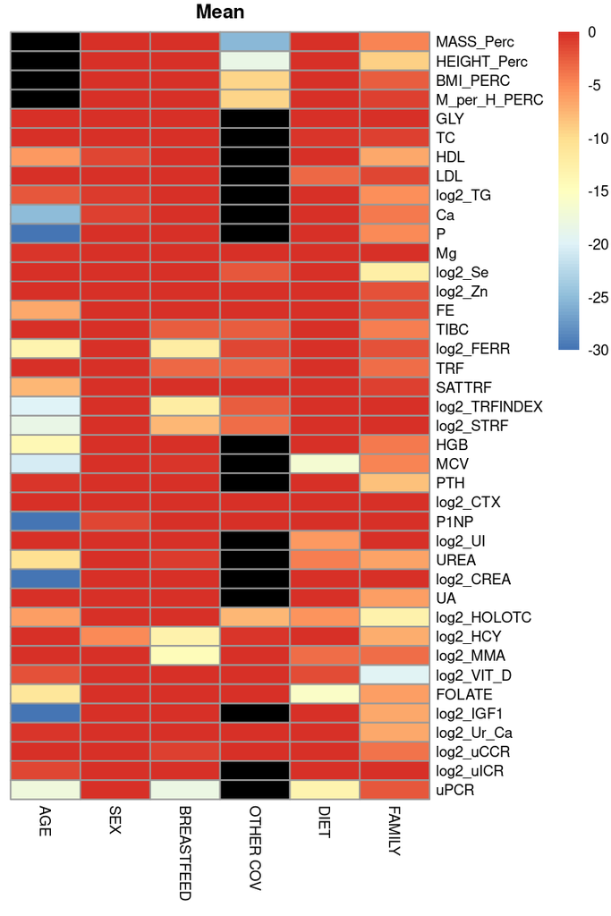

Heatmap showing decrease in the Akaike Information Criterion (AIC) after the addition of a given variable to a mixed-effects model in children. The AIC change reflects the impact of the variable on out-of-sample predictive accuracy, with values bounded between -30 (high importance, shown in blue) and 0 (no or negligible importance, shown in red). Black indicates that the variable was not included in the model (e.g., inapplicable supplementation-related variables)

```r
heat_map(AIC_child_all, mixef = TRUE)
```

## 2.2 Adults

### 2.2.1 Diet effects

#### 2.2.1.1 Unstandardized effects

**Open code**

```r
diet_adult <- read.xlsx("gitignore/data/diet_adult_mixeff.xlsx") %>%
  mutate(outcome = clean_outcome_names(outcome)) %>%
    mutate(outcome = case_when(
      outcome == "FOLAT" ~ "FOLATE",
      outcome == "log2_VKFE" ~ "log2_TIBC",
      outcome == "Cros" ~ "CTX",
      outcome == "log2_Cros" ~ "log2_CTX",
      outcome == "VIT_AKTB12" ~ "HOLOTC",
      outcome == "log2_VIT_AKTB12" ~ "log2_HOLOTC",

      outcome == "log2_Ur_Ca" ~ "log2_uCa",
      outcome == "log2_Ca_per_Krea" ~ "log2_uCCR",
      outcome == "log2_I_per_Krea" ~ "log2_uICR",
      outcome == "P_per_Krea" ~ "uPCR",
      outcome == "log2_P_per_Krea" ~ "log2_uPCR",
      TRUE ~ outcome
    ))

  diet_adult2 <- diet_adult %>%
    mutate(across(
      .cols = c(VN_OM_diff, VG_OM_diff, VN_VG_diff),
      ~ round(.x, 2)
    ))

  kbl(diet_adult2,
    caption =
      "Differences in clinical outcomes (`outcome`) between diet groups in adults, estimated using robust linear mixed-effects models. For each outcome, the table reports the estimated difference (`[...]_diff`), raw p-value (`[...]_P`), and FDR-corrected p-value (`[...]_P_adj`) for multiple comparisons. Comparisons include (A) vegans vs. omnivores (`VN_OM`), (B) vegetarians vs. omnivores (`VG_OM`), and (C) vegans vs. vegetarians (`VN_VG`)."
  ) %>%
    kable_styling("striped", full_width = T) %>%
    add_header_above(c(
      " " = 2, "(A) VN vs OM" = 3,
      "(B) VG vs OM" = 3, "(C) VN vs VG" = 3
    )) %>%
    column_spec(1, width_min = "1.5in")
```

Differences in clinical outcomes (`outcome`) between diet groups in adults, estimated using robust linear mixed-effects models. For each outcome, the table reports the estimated difference (`[...]_diff`), raw p-value (`[...]_P`), and FDR-corrected p-value (`[...]_P_adj`) for multiple comparisons. Comparisons include (A) vegans vs. omnivores (`VN_OM`), (B) vegetarians vs. omnivores (`VG_OM`), and (C) vegans vs. vegetarians (`VN_VG`).

| outcome | estimand | (A) VN vs OM VN_OM_diff | (A) VN vs OM VN_OM_P | (A) VN vs OM VN_OM_P_adj | (B) VG vs OM VG_OM_diff | (B) VG vs OM VG_OM_P | (B) VG vs OM VG_OM_P_adj | (C) VN vs VG VN_VG_diff | (C) VN vs VG VN_VG_P | (C) VN vs VG VN_VG_P_adj |
| --- | --- | --- | --- | --- | --- | --- | --- | --- | --- | --- |
| BMI | mean | -1.32 | 0.02339 | 0.08455 | -0.88 | 0.18962 | 0.49849 | -0.44 | 0.46534 | 0.68346 |
| WHR | mean | -0.01 | 0.14670 | 0.30981 | 0.00 | 0.98174 | 0.98786 | -0.01 | 0.15240 | 0.41124 |
| HEIGHT | mean | -0.01 | 0.57922 | 0.71114 | 0.00 | 0.77318 | 0.92348 | -0.01 | 0.38939 | 0.60276 |
| MASS | mean | -3.90 | 0.05222 | 0.15554 | -1.34 | 0.56242 | 0.75241 | -2.56 | 0.21763 | 0.44840 |
| HG | mean | 0.52 | 0.67431 | 0.73703 | 1.06 | 0.45491 | 0.71270 | -0.54 | 0.66808 | 0.87222 |
| PFAT | mean | -1.80 | 0.13113 | 0.29349 | -0.02 | 0.98786 | 0.98786 | -1.78 | 0.14847 | 0.41124 |
| log2_FAT | mean | -0.20 | 0.08307 | 0.20548 | -0.01 | 0.92471 | 0.98786 | -0.19 | 0.11576 | 0.41124 |
| log2_FFM | mean | -0.06 | 0.03242 | 0.10884 | -0.02 | 0.47136 | 0.71465 | -0.03 | 0.20516 | 0.44840 |
| SBP | mean | -4.13 | 0.11534 | 0.27104 | -3.15 | 0.29789 | 0.60872 | -0.98 | 0.71735 | 0.88481 |
| DBP | mean | -2.32 | 0.15161 | 0.30981 | 1.96 | 0.29481 | 0.60872 | -4.28 | 0.01050 | 0.09871 |
| GLY | mean | -0.09 | 0.23697 | 0.40141 | -0.07 | 0.37425 | 0.65147 | -0.01 | 0.87870 | 0.95109 |
| log2_TC | mean | -0.21 | 0.00003 | 0.00026 | -0.15 | 0.01053 | 0.09898 | -0.06 | 0.24578 | 0.44840 |
| HDL | mean | -0.04 | 0.55224 | 0.70150 | -0.07 | 0.31978 | 0.61085 | 0.03 | 0.59208 | 0.81847 |
| LDL | mean | -0.50 | 0.00003 | 0.00026 | -0.32 | 0.02052 | 0.12406 | -0.18 | 0.14232 | 0.41124 |
| log2_TG | mean | -0.12 | 0.27029 | 0.43806 | -0.10 | 0.43165 | 0.71270 | -0.02 | 0.85003 | 0.95109 |
| Ca | mean | 0.01 | 0.63437 | 0.71256 | 0.01 | 0.60664 | 0.77060 | 0.00 | 0.90874 | 0.95109 |
| P | mean | -0.03 | 0.20320 | 0.38201 | 0.00 | 0.96848 | 0.98786 | -0.03 | 0.23478 | 0.44840 |
| Mg | mean | 0.00 | 0.83778 | 0.87502 | 0.00 | 0.88936 | 0.98786 | 0.00 | 0.72386 | 0.88481 |
| log2_Se | mean | -0.11 | 0.30324 | 0.47507 | -0.16 | 0.19091 | 0.49849 | 0.05 | 0.63508 | 0.85282 |
| log2_Zn | mean | -0.22 | 0.00001 | 0.00010 | -0.13 | 0.02053 | 0.12406 | -0.09 | 0.07562 | 0.35541 |
| FE | mean | 0.18 | 0.89367 | 0.89367 | -2.49 | 0.10966 | 0.37364 | 2.67 | 0.05666 | 0.33579 |
| log2_TIBC | mean | 0.03 | 0.32440 | 0.49183 | 0.04 | 0.32492 | 0.61085 | 0.00 | 0.89083 | 0.95109 |
| log2_FERR | mean | -0.74 | 0.00000 | 0.00010 | -0.55 | 0.00340 | 0.04000 | -0.20 | 0.23528 | 0.44840 |
| log2_TRF | mean | 0.03 | 0.35077 | 0.50011 | 0.03 | 0.35959 | 0.65002 | 0.00 | 0.91062 | 0.95109 |
| SATTRF | mean | -0.36 | 0.86237 | 0.88111 | -4.20 | 0.07837 | 0.33487 | 3.84 | 0.07404 | 0.35541 |
| log2_TRFINDEX | mean | 0.25 | 0.00312 | 0.01466 | 0.30 | 0.00189 | 0.02955 | -0.05 | 0.55376 | 0.78868 |
| log2_STRF | mean | 0.04 | 0.47448 | 0.63715 | 0.10 | 0.11130 | 0.37364 | -0.06 | 0.28159 | 0.45637 |
| HGB | mean | -1.09 | 0.52297 | 0.68277 | -1.10 | 0.57631 | 0.75241 | 0.01 | 0.99550 | 0.99742 |
| MCV | mean | 1.66 | 0.00706 | 0.03018 | -0.82 | 0.25060 | 0.56088 | 2.48 | 0.00010 | 0.00467 |
| PTH | mean | 0.37 | 0.05295 | 0.15554 | -0.15 | 0.49051 | 0.71697 | 0.52 | 0.00818 | 0.09615 |
| log2_CTX | mean | 0.05 | 0.71938 | 0.76843 | -0.10 | 0.53386 | 0.73798 | 0.15 | 0.27323 | 0.45637 |
| log2_P1NP | mean | 0.14 | 0.23914 | 0.40141 | 0.01 | 0.95007 | 0.98786 | 0.13 | 0.25759 | 0.44840 |
| log2_UI | mean | -0.41 | 0.16036 | 0.31403 | -0.51 | 0.13466 | 0.39556 | 0.10 | 0.73421 | 0.88481 |
| log2_UREA | mean | -0.29 | 0.00002 | 0.00022 | -0.10 | 0.20526 | 0.50774 | -0.19 | 0.00627 | 0.09615 |
| log2_CREA | mean | -0.13 | 0.00096 | 0.00562 | -0.07 | 0.11007 | 0.37364 | -0.06 | 0.15750 | 0.41124 |
| UA | mean | -5.57 | 0.59209 | 0.71114 | -8.03 | 0.50340 | 0.71697 | 2.46 | 0.81915 | 0.95109 |
| log2_HOLOTC | mean | -0.09 | 0.60522 | 0.71114 | -0.30 | 0.07083 | 0.33487 | 0.21 | 0.13576 | 0.41124 |
| log2_HCY | mean | -0.04 | 0.63675 | 0.71256 | 0.11 | 0.23261 | 0.54663 | -0.15 | 0.05716 | 0.33579 |
| log2_MMA | mean | 0.14 | 0.22342 | 0.40141 | 0.41 | 0.00026 | 0.01229 | -0.26 | 0.00521 | 0.09615 |
| log2_VIT_D | mean | 0.24 | 0.00226 | 0.01178 | 0.14 | 0.13009 | 0.39556 | 0.10 | 0.18156 | 0.43844 |
| FOLATE | mean | 3.27 | 0.00019 | 0.00125 | 3.27 | 0.00118 | 0.02761 | 0.00 | 0.99742 | 0.99742 |
| log2_uCa | mean | -0.51 | 0.06027 | 0.16663 | -0.15 | 0.63420 | 0.78441 | -0.37 | 0.18657 | 0.43844 |
| log2_uCCR | mean | -0.16 | 0.36178 | 0.50011 | -0.01 | 0.97077 | 0.98786 | -0.16 | 0.39756 | 0.60276 |
| log2_uICR | mean | -0.29 | 0.35971 | 0.50011 | -0.67 | 0.07375 | 0.33487 | 0.37 | 0.25137 | 0.44840 |
| uPCR | mean | -0.62 | 0.00000 | 0.00010 | -0.35 | 0.02112 | 0.12406 | -0.28 | 0.04185 | 0.32786 |
| AL_adult | log(OR) | -1.95 | 0.01704 | 0.06673 | -0.61 | 0.44626 | 0.71270 | -1.34 | 0.08705 | 0.37193 |
| BREAKS | log(OR) | -0.69 | 0.07545 | 0.19700 | -0.12 | 0.78594 | 0.92348 | -0.57 | 0.15320 | 0.41124 |

#### 2.2.1.2 Standardized effects by 1SD

**Open code**

```r
meds <- diet_adult %>% filter(estimand == "mean")

ids <- nrow(meds)
sds <- vector("double", ids)
sds
##  [1] 0 0 0 0 0 0 0 0 0 0 0 0 0 0 0 0 0 0 0 0 0 0 0 0 0 0 0 0 0 0 0 0 0 0 0 0 0 0
## [39] 0 0 0 0 0 0 0

before_outcome_col <- which(colnames(dat_adult) == 'aBMI')-1

for (i in 1:ids) {
  sds[i] <- ifelse(grepl("log2", diet_adult[(i), 1]),
    sd(log2(dat_adult[, (i + before_outcome_col)]), na.rm = TRUE),
    sd(     dat_adult[, (i + before_outcome_col)] , na.rm = TRUE)
  )
}

sds[(ids+1) : (ids+2)] <- 1

diet_adult_Z <- diet_adult %>%
  mutate(SD = sds) %>%
  mutate(
    VN_OM_diff = VN_OM_diff / SD,
    VG_OM_diff = VG_OM_diff / SD,
    VN_VG_diff = VN_VG_diff / SD
  ) %>%
  select(-SD) %>%
  mutate(VG_OM_P = if_else(VG_OM_P < 1e-5, 1e-5, VG_OM_P)) %>%
  mutate(across(.cols = c(VN_OM_diff, VG_OM_diff, VN_VG_diff), ~ round(.x, 2)))


kbl(diet_adult_Z,
  caption =
    "Standardized differences in clinical outcomes (`outcome`) between diet groups in children, estimated using robust linear mixed-effects models. For each outcome, the table reports the estimated difference (`[...]_diff`), raw p-value (`[...]_P`), and FDR-corrected p-value (`[...]_P_adj`) for multiple comparisons. Comparisons include (A) vegans vs. omnivores (`VN_OM`), (B) vegetarians vs. omnivores (`VG_OM`), and (C) vegans vs. vegetarians (`VN_VG`)."
) %>%
  kable_styling("striped", full_width = T) %>%
  add_header_above(c(
    " " = 2, "(A) VN vs OM" = 3,
    "(B) VG vs OM" = 3, "(C) VN vs VG" = 3
  )) %>%
  column_spec(1, width_min = "1.5in")
```

| outcome | estimand | (A) VN vs OM VN_OM_diff | (A) VN vs OM VN_OM_P | (A) VN vs OM VN_OM_P_adj | (B) VG vs OM VG_OM_diff | (B) VG vs OM VG_OM_P | (B) VG vs OM VG_OM_P_adj | (C) VN vs VG VN_VG_diff | (C) VN vs VG VN_VG_P | (C) VN vs VG VN_VG_P_adj |
| --- | --- | --- | --- | --- | --- | --- | --- | --- | --- | --- |
| BMI | mean | -0.37 | 0.02339 | 0.08455 | -0.25 | 0.18962 | 0.49849 | -0.12 | 0.46534 | 0.68346 |
| WHR | mean | -0.20 | 0.14670 | 0.30981 | 0.00 | 0.98174 | 0.98786 | -0.21 | 0.15240 | 0.41124 |
| HEIGHT | mean | -0.09 | 0.57922 | 0.71114 | 0.05 | 0.77318 | 0.92348 | -0.14 | 0.38939 | 0.60276 |
| MASS | mean | -0.28 | 0.05222 | 0.15554 | -0.10 | 0.56242 | 0.75241 | -0.18 | 0.21763 | 0.44840 |
| HG | mean | 0.04 | 0.67431 | 0.73703 | 0.08 | 0.45491 | 0.71270 | -0.04 | 0.66808 | 0.87222 |
| PFAT | mean | -0.22 | 0.13113 | 0.29349 | 0.00 | 0.98786 | 0.98786 | -0.22 | 0.14847 | 0.41124 |
| log2_FAT | mean | -0.29 | 0.08307 | 0.20548 | -0.02 | 0.92471 | 0.98786 | -0.27 | 0.11576 | 0.41124 |
| log2_FFM | mean | -0.19 | 0.03242 | 0.10884 | -0.08 | 0.47136 | 0.71465 | -0.12 | 0.20516 | 0.44840 |
| SBP | mean | -0.24 | 0.11534 | 0.27104 | -0.19 | 0.29789 | 0.60872 | -0.06 | 0.71735 | 0.88481 |
| DBP | mean | -0.25 | 0.15161 | 0.30981 | 0.21 | 0.29481 | 0.60872 | -0.46 | 0.01050 | 0.09871 |
| GLY | mean | -0.17 | 0.23697 | 0.40141 | -0.15 | 0.37425 | 0.65147 | -0.02 | 0.87870 | 0.95109 |
| log2_TC | mean | -0.71 | 0.00003 | 0.00026 | -0.51 | 0.01053 | 0.09898 | -0.21 | 0.24578 | 0.44840 |
| HDL | mean | -0.09 | 0.55224 | 0.70150 | -0.18 | 0.31978 | 0.61085 | 0.08 | 0.59208 | 0.81847 |
| LDL | mean | -0.70 | 0.00003 | 0.00026 | -0.45 | 0.02052 | 0.12406 | -0.25 | 0.14232 | 0.41124 |
| log2_TG | mean | -0.17 | 0.27029 | 0.43806 | -0.14 | 0.43165 | 0.71270 | -0.03 | 0.85003 | 0.95109 |
| Ca | mean | 0.08 | 0.63437 | 0.71256 | 0.10 | 0.60664 | 0.77060 | -0.02 | 0.90874 | 0.95109 |
| P | mean | -0.20 | 0.20320 | 0.38201 | -0.01 | 0.96848 | 0.98786 | -0.19 | 0.23478 | 0.44840 |
| Mg | mean | 0.03 | 0.83778 | 0.87502 | -0.03 | 0.88936 | 0.98786 | 0.06 | 0.72386 | 0.88481 |
| log2_Se | mean | -0.22 | 0.30324 | 0.47507 | -0.33 | 0.19091 | 0.49849 | 0.11 | 0.63508 | 0.85282 |
| log2_Zn | mean | -0.81 | 0.00001 | 0.00010 | -0.48 | 0.02053 | 0.12406 | -0.33 | 0.07562 | 0.35541 |
| FE | mean | 0.02 | 0.89367 | 0.89367 | -0.31 | 0.10966 | 0.37364 | 0.33 | 0.05666 | 0.33579 |
| log2_TIBC | mean | 0.16 | 0.32440 | 0.49183 | 0.18 | 0.32492 | 0.61085 | -0.02 | 0.89083 | 0.95109 |
| log2_FERR | mean | -0.60 | 0.00000 | 0.00010 | -0.44 | 0.00340 | 0.04000 | -0.16 | 0.23528 | 0.44840 |
| log2_TRF | mean | 0.15 | 0.35077 | 0.50011 | 0.17 | 0.35959 | 0.65002 | -0.02 | 0.91062 | 0.95109 |
| SATTRF | mean | -0.03 | 0.86237 | 0.88111 | -0.33 | 0.07837 | 0.33487 | 0.30 | 0.07404 | 0.35541 |
| log2_TRFINDEX | mean | 0.47 | 0.00312 | 0.01466 | 0.56 | 0.00189 | 0.02955 | -0.10 | 0.55376 | 0.78868 |
| log2_STRF | mean | 0.09 | 0.47448 | 0.63715 | 0.24 | 0.11130 | 0.37364 | -0.15 | 0.28159 | 0.45637 |
| HGB | mean | -0.07 | 0.52297 | 0.68277 | -0.07 | 0.57631 | 0.75241 | 0.00 | 0.99550 | 0.99742 |
| MCV | mean | 0.39 | 0.00706 | 0.03018 | -0.19 | 0.25060 | 0.56088 | 0.58 | 0.00010 | 0.00467 |
| PTH | mean | 0.31 | 0.05295 | 0.15554 | -0.13 | 0.49051 | 0.71697 | 0.44 | 0.00818 | 0.09615 |
| log2_CTX | mean | 0.06 | 0.71938 | 0.76843 | -0.13 | 0.53386 | 0.73798 | 0.19 | 0.27323 | 0.45637 |
| log2_P1NP | mean | 0.23 | 0.23914 | 0.40141 | 0.01 | 0.95007 | 0.98786 | 0.22 | 0.25759 | 0.44840 |
| log2_UI | mean | -0.26 | 0.16036 | 0.31403 | -0.32 | 0.13466 | 0.39556 | 0.06 | 0.73421 | 0.88481 |
| log2_UREA | mean | -0.69 | 0.00002 | 0.00022 | -0.24 | 0.20526 | 0.50774 | -0.46 | 0.00627 | 0.09615 |
| log2_CREA | mean | -0.45 | 0.00096 | 0.00562 | -0.25 | 0.11007 | 0.37364 | -0.20 | 0.15750 | 0.41124 |
| UA | mean | -0.08 | 0.59209 | 0.71114 | -0.11 | 0.50340 | 0.71697 | 0.03 | 0.81915 | 0.95109 |
| log2_HOLOTC | mean | -0.13 | 0.60522 | 0.71114 | -0.43 | 0.07083 | 0.33487 | 0.31 | 0.13576 | 0.41124 |
| log2_HCY | mean | -0.08 | 0.63675 | 0.71256 | 0.21 | 0.23261 | 0.54663 | -0.29 | 0.05716 | 0.33579 |
| log2_MMA | mean | 0.21 | 0.22342 | 0.40141 | 0.60 | 0.00026 | 0.01229 | -0.39 | 0.00521 | 0.09615 |
| log2_VIT_D | mean | 0.55 | 0.00226 | 0.01178 | 0.32 | 0.13009 | 0.39556 | 0.24 | 0.18156 | 0.43844 |
| FOLATE | mean | 0.67 | 0.00019 | 0.00125 | 0.67 | 0.00118 | 0.02761 | 0.00 | 0.99742 | 0.99742 |
| log2_uCa | mean | -0.39 | 0.06027 | 0.16663 | -0.11 | 0.63420 | 0.78441 | -0.28 | 0.18657 | 0.43844 |
| log2_uCCR | mean | -0.16 | 0.36178 | 0.50011 | -0.01 | 0.97077 | 0.98786 | -0.15 | 0.39756 | 0.60276 |
| log2_uICR | mean | -0.18 | 0.35971 | 0.50011 | -0.41 | 0.07375 | 0.33487 | 0.23 | 0.25137 | 0.44840 |
| uPCR | mean | -0.76 | 0.00000 | 0.00010 | -0.42 | 0.02112 | 0.12406 | -0.33 | 0.04185 | 0.32786 |
| AL_adult | log(OR) | -1.95 | 0.01704 | 0.06673 | -0.61 | 0.44626 | 0.71270 | -1.34 | 0.08705 | 0.37193 |
| BREAKS | log(OR) | -0.69 | 0.07545 | 0.19700 | -0.12 | 0.78594 | 0.92348 | -0.57 | 0.15320 | 0.41124 |

#### 2.2.1.3 Vulcano plots

VN vs OM

**Open code**

```r
plotac <- "fig31"

path <- paste0("gitignore/figures/", plotac, ".rds")

if (file.exists(path) == FALSE) {
  assign(plotac, diet_adult_Z %>%
    filter(estimand != "log(OR)") %>%

    mutate(
      pv_adj = VN_OM_P_adj,
      pv_raw = VN_OM_P,
      b_coe = VN_OM_diff
    ) %>%
    mutate(
      pv_adj = VN_OM_P_adj,
      pv_raw = VN_OM_P,
      b_coe = VN_OM_diff
    ) %>%
    mutate(pv_raw = if_else(pv_raw < 1e-5, 1e-5, pv_raw)) %>%
    mutate(
      m_ylab = -log10(pv_raw),
      m_xlab = b_coe,
      rescat = if_else(
        pv_raw >= 0.05,
        "P>0.05",
        if_else(
          b_coe > 0,
          "VN+",
          "OM+"
        )
      )
    ) %>%
    mutate(
      rescat = factor(rescat,
        levels = c("OM+", "VN+", "P>0.05")
      ),
      meta_labels = if_else(pv_raw < 0.05, outcome, "")
    ) %>%
    ggplot(aes(
      x = b_coe,
      y = m_ylab,
      color = rescat,
      alpha = rescat,
      label = meta_labels
    )) +
    geom_point(size = 2, shape = 16, alpha = 0.6) +
    geom_text_repel(
      aes(
        x = m_xlab,
        y = m_ylab
      ),
      show.legend = FALSE,
      alpha = 1,
      box.padding = 0.7,
      size = 3.1,
      seed = 17
    ) +
    labs(x = "Standardized difference", y = "-log10 (P-value)") +
    scale_color_manual(values = color_map, name = "") +
    ggtitle("VN vs. OM, adults") +
    theme(
      legend.text = element_text(size = 11),
      axis.title = element_text(size = 12)
    ) +
    coord_cartesian(
      ylim = c(0, 5),
      xlim = c(-1.7, 1.7)
    ))

  saveRDS(get(plotac), file = path)
} else {
  assign(plotac, readRDS(path))
}
```

VG vs OM

**Open code**

```r
plotac <- "fig32"

path <- paste0("gitignore/figures/", plotac, ".rds")

if (file.exists(path) == FALSE) {
  assign(plotac, diet_adult_Z %>%
    filter(estimand != "log(OR)") %>%

    mutate(
      pv_adj = VG_OM_P_adj,
      pv_raw = VG_OM_P,
      b_coe = VG_OM_diff
    ) %>%
    mutate(pv_raw = if_else(pv_raw < 1e-5, 1e-5, pv_raw)) %>%
    mutate(
      m_ylab = -log10(pv_raw),
      m_xlab = b_coe,
      rescat = if_else(
        pv_raw >= 0.05,
        "P>0.05",
        if_else(
          b_coe > 0,
          "VG+",
          "OM+"
        )
      )
    ) %>%
    mutate(
      rescat = factor(rescat,
        levels = c("OM+", "VG+", "P>0.05")
      ),
      meta_labels = if_else(pv_raw < 0.05, outcome, "")
    ) %>%
    ggplot(aes(
      x = b_coe,
      y = m_ylab,
      color = rescat,
      alpha = rescat,
      label = meta_labels
    )) +
    geom_point(size = 2, shape = 16, alpha = 0.6) +
    geom_text_repel(
      aes(
        x = m_xlab,
        y = m_ylab
      ),
      show.legend = FALSE,
      alpha = 1,
      box.padding = 0.6,
      size = 3.1,
      seed = 17
    ) +
    labs(x = "Standardized difference", y = "-log10 (P-value)") +
    scale_color_manual(values = color_map, name = "") +
    ggtitle("VG vs OM, adults") +
    theme(
      legend.text = element_text(size = 11),
      axis.title = element_text(size = 12)
    ) +
    coord_cartesian(
      ylim = c(0, 5),
      xlim = c(-1.7, 1.7)
    ))

  saveRDS(get(plotac), file = path)
} else {
  assign(plotac, readRDS(path))
}
```

VN vs VG

**Open code**

```r
plotac <- "fig33"

path <- paste0("gitignore/figures/", plotac, ".rds")

if (file.exists(path) == FALSE) {
  assign(plotac, diet_adult_Z %>%
    filter(estimand != "log(OR)") %>%
    mutate(
      pv_adj = VN_VG_P_adj,
      pv_raw = VN_VG_P,
      b_coe = VN_VG_diff
    ) %>%
    mutate(pv_raw = if_else(pv_raw < 1e-5, 1e-5, pv_raw)) %>%
    mutate(
      m_ylab = -log10(pv_raw),
      m_xlab = b_coe,
      rescat = if_else(
        pv_raw >= 0.05,
        "P>0.05",
        if_else(
          b_coe > 0,
          "VN+",
          "VG+"
        )
      )
    ) %>%
    mutate(
      rescat = factor(rescat,
        levels = c(
          "VG+",
          "VN+",
          "P>0.05"
        )
      ),
      meta_labels = if_else(pv_raw < 0.05, outcome, "")
    ) %>%
    ggplot(aes(
      x = b_coe,
      y = m_ylab,
      color = rescat,
      alpha = rescat,
      label = meta_labels
    )) +
    geom_point(size = 2, shape = 16, alpha = 0.6) +
    geom_text_repel(
      aes(
        x = m_xlab,
        y = m_ylab
      ),
      show.legend = FALSE,
      alpha = 1,
      box.padding = 0.6,
      size = 3.1,
      seed = 16
    ) +
    labs(
      x = "Standardized difference",
      y = "-log10 (P-value)"
    ) +
    scale_color_manual(values = color_map, name = "") +
    ggtitle("VN vs VG, adults") +
    theme(
      legend.text = element_text(size = 11),
      axis.title = element_text(size = 12)
    ) +
    coord_cartesian(
      ylim = c(0, 5),
      xlim = c(-1.7, 1.7)
    ))

  saveRDS(get(plotac), file = path)
} else {
  assign(plotac, readRDS(path))
}
```

### 2.2.2 Covariates importance

#### 2.2.2.1 Table

**Open code**

```r
AIC_adult <- read.xlsx("gitignore/data/AIC_adult_mixeff.xlsx") %>%
  mutate(across(where(is.numeric), ~ round(., 1))) %>%
  mutate(outcome = clean_outcome_names(outcome)) %>%
  filter(!outcome %in% c("AL_adult", "BREAKS")) %>%
  rename(
    SEX = aSEX,
    `OTHER COV` = other_cov,
    FAMILY = family,
    DIET = diet,
    AGE = aAGE
  ) %>%
  mutate(outcome = case_when(
    outcome == "FOLAT" ~ "FOLATE",
    outcome == "VKFE" ~ "TIBC",
    outcome == "Cros" ~ "CTX",
    outcome == "log2_Cros" ~ "log2_CTX",
    outcome == "VIT_AKTB12" ~ "HOLOTC",
    outcome == "log2_VIT_AKTB12" ~ "log2_HOLOTC",

    outcome == 'log2_aUr_Ca' ~ 'log2_uCa',
    outcome == 'log2_Ca_per_Krea' ~ 'log2_uCCR',
    outcome == 'log2_I_per_Krea' ~ 'log2_uICR',
    outcome == 'P_per_Krea' ~ 'uPCR',
    outcome == 'log2_P_per_Krea' ~ 'log2_uPCR',
    TRUE ~ outcome
  ))

kbl(AIC_adult,
  caption =
    "Change of the Akaike Information Criterion (AIC) after addition of a given variable to mixed effects models for adults. The magnitude of the AIC change indicates the impact on out-of-sample predictive accuracy, with more negative values reflecting greater importance of the variable."
) %>%
  kable_styling("striped", full_width = T) %>%
  column_spec(1, width_min = "1.5in")
```

Change of the Akaike Information Criterion (AIC) after addition of a given variable to mixed effects models for adults. The magnitude of the AIC change indicates the impact on out-of-sample predictive accuracy, with more negative values reflecting greater importance of the variable.

| outcome | estimand | AGE | SEX | OTHER COV | DIET | FAMILY |
| --- | --- | --- | --- | --- | --- | --- |
| BMI | mean | 1.6 | -11.9 | NA | 0.0 | 0.4 |
| WHR | mean | -2.7 | -79.2 | NA | 0.6 | 1.5 |
| HEIGHT | mean | 1.6 | -104.7 | NA | 3.4 | -5.3 |
| MASS | mean | 1.0 | -71.7 | NA | -0.9 | -1.3 |
| HG | mean | 0.8 | -228.4 | NA | 3.3 | -2.0 |
| PFAT | mean | 0.0 | -90.2 | NA | 1.9 | -0.6 |
| log2_FAT | mean | 0.1 | -18.7 | NA | 0.5 | 0.5 |
| log2_FFM | mean | 2.1 | -249.1 | NA | -1.2 | 2.0 |
| SBP | mean | 1.5 | -47.3 | NA | 0.8 | 1.7 |
| DBP | mean | 1.2 | -6.8 | NA | -4.4 | 1.6 |
| GLY | mean | 1.9 | -3.9 | NA | 2.6 | 1.5 |
| log2_TC | mean | -1.3 | -2.7 | NA | -11.5 | 2.0 |
| HDL | mean | -2.4 | -66.5 | NA | 3.1 | -1.1 |
| LDL | mean | 1.3 | 1.8 | NA | -9.8 | 1.6 |
| log2_TG | mean | 1.8 | -21.2 | NA | 2.8 | -1.7 |
| Ca | mean | 1.2 | -19.7 | NA | 4.0 | -0.3 |
| P | mean | 1.6 | -41.2 | NA | 2.4 | 1.9 |
| Mg | mean | 2.0 | 1.2 | 2.0 | 3.4 | 2.2 |
| log2_Se | mean | 2.1 | 0.4 | 0.0 | 2.1 | -37.2 |
| log2_Zn | mean | 1.1 | -3.0 | 0.7 | -8.6 | -24.0 |
| FE | mean | 1.9 | -7.8 | 1.3 | 3.3 | 0.9 |
| log2_VKFE | mean | 1.7 | -13.0 | 2.1 | 2.6 | -2.4 |
| log2_FERR | mean | 1.8 | -72.1 | 1.3 | -14.0 | -4.3 |
| log2_TRF | mean | 1.6 | -12.8 | 2.2 | 2.7 | -2.7 |
| SATTRF | mean | 1.8 | -14.9 | 1.6 | 3.5 | 0.2 |
| log2_TRFINDEX | mean | 2.1 | -41.2 | -0.7 | -6.1 | -1.4 |
| log2_STRF | mean | 1.9 | 2.2 | -1.1 | 2.3 | 2.1 |
| HGB | mean | 0.5 | -71.0 | NA | 3.2 | 0.5 |
| MCV | mean | 1.1 | -5.1 | NA | -2.8 | 2.1 |
| PTH | mean | 0.9 | 1.0 | NA | -5.2 | -0.4 |
| log2_CTX | mean | -8.7 | 1.7 | 2.9 | 3.1 | 2.2 |
| log2_P1NP | mean | -6.3 | 2.2 | 0.4 | 1.6 | 2.2 |
| log2_UI | mean | -1.0 | 1.2 | NA | 1.4 | -44.4 |
| log2_UREA | mean | 0.4 | -16.3 | NA | -12.3 | 0.3 |
| log2_CREA | mean | -0.1 | -74.7 | NA | -4.8 | 0.5 |
| UA | mean | -2.8 | -87.8 | NA | 3.7 | 1.3 |
| log2_HOLOTC | mean | 2.1 | -7.6 | -0.4 | -0.4 | -13.3 |
| log2_HCY | mean | 2.2 | -55.6 | 2.2 | 2.2 | -1.6 |
| log2_MMA | mean | -0.6 | -1.7 | -9.9 | -5.1 | 0.9 |
| log2_VIT_D | mean | 1.4 | 2.1 | 0.7 | -3.3 | -6.4 |
| FOLATE | mean | 1.2 | -14.8 | -2.7 | -8.7 | -12.5 |
| log2_Ur_Ca | mean | 1.5 | -14.4 | 1.4 | 0.3 | -8.5 |
| log2_uCCR | mean | 0.7 | 1.7 | 1.6 | 2.9 | 0.4 |
| log2_uICR | mean | -3.5 | -12.4 | NA | 1.6 | -14.9 |
| uPCR | mean | 2.0 | -14.5 | NA | -13.5 | -3.6 |

#### 2.2.2.2 Heatmap

**Open code**

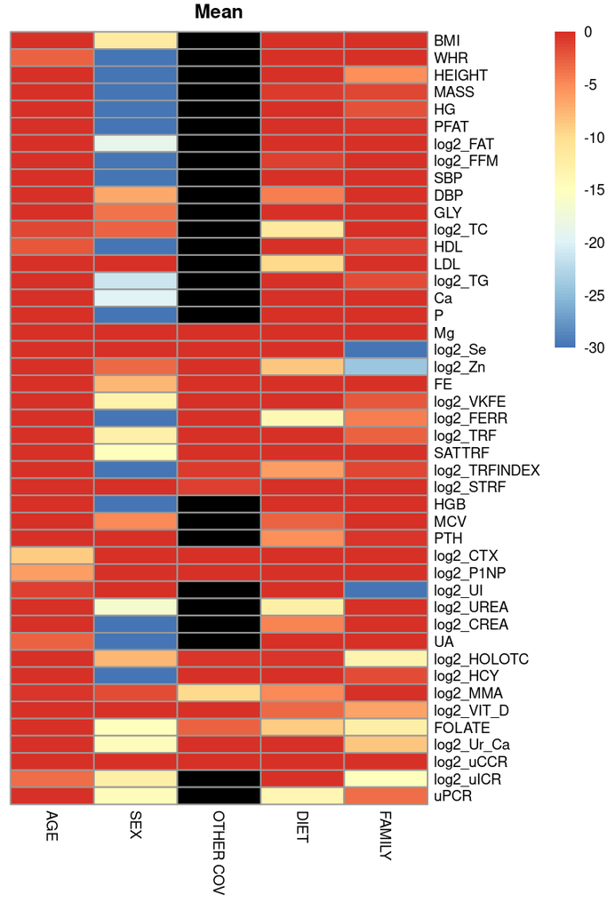

Heatmap showing decrease in the Akaike Information Criterion (AIC) after the addition of a given variable to a mixed-effects model in adults. The AIC change reflects the impact of the variable on out-of-sample predictive accuracy, with values bounded between -30 (high importance, shown in blue) and 0 (no or negligible importance, shown in red). Black indicates that the variable was not included in the model (e.g., inapplicable supplementation-related variables)

```r
heat_map(AIC_adult, mixef = TRUE)
```

## 2.3 Vulcano matrix

Prepare

**Open code**

```r
plotac <- "fig35"
path <- paste0("gitignore/figures/", plotac, ".rds")

if (file.exists(path) == FALSE) {
  fig19 <- fig19 + theme(
    legend.position = "none",
    plot.title = element_blank()
  )
  fig20 <- fig20 + theme(
    legend.position = "none",
    plot.title = element_blank()
  )
  fig21 <- fig21 + theme(
    legend.position = "none",
    plot.title = element_blank()
  )

  fig31 <- fig31 + theme(
    legend.position = "bottom",
    plot.title = element_blank()
  )
  fig32 <- fig32 + theme(
    legend.position = "bottom",
    plot.title = element_blank()
  )
  fig33 <- fig33 + theme(
    legend.position = "bottom",
    plot.title = element_blank()
  )
}
```

Create subfigures

**Open code**

```r
if (file.exists(path) == FALSE) {
  children_volc <- ggarrange(
    fig19 +
      theme(
        axis.text.x = element_blank(),
        axis.ticks.x = element_blank(),
        axis.title.x = element_blank()
      ),
    fig20 +
      theme(
        axis.text.y = element_blank(),
        axis.ticks.y = element_blank(),
        axis.title.y = element_blank(),
        axis.text.x = element_blank(),
        axis.ticks.x = element_blank(),
        axis.title.x = element_blank()
      ),
    fig21 +
      theme(
        axis.text.y = element_blank(),
        axis.ticks.y = element_blank(),
        axis.title.y = element_blank(),
        axis.text.x = element_blank(),
        axis.ticks.x = element_blank(),
        axis.title.x = element_blank()
      ),
    nrow = 1,
    ncol = 3,
    widths = c(1.1, 1, 1),
    labels = c("A", "", "")
  )

  children_volc <- annotate_figure(
    children_volc,
    top = text_grob("Children", face = "bold", size = 10)
  )


  adult_volc <- ggarrange(
    fig31,
    fig32 +
      theme(
        axis.text.y = element_blank(),
        axis.ticks.y = element_blank(),
        axis.title.y = element_blank()
      ),
    fig33 +
      theme(
        axis.text.y = element_blank(),
        axis.ticks.y = element_blank(),
        axis.title.y = element_blank()
      ),
    nrow = 1,
    ncol = 3,
    widths = c(1.1, 1, 1),
    labels = c("B", "", "")
  )

  adult_volc <- annotate_figure(
    adult_volc,
    top = text_grob("Adults", face = "bold", size = 10)
  )
}
```

### 2.3.1 Print

**Open code**

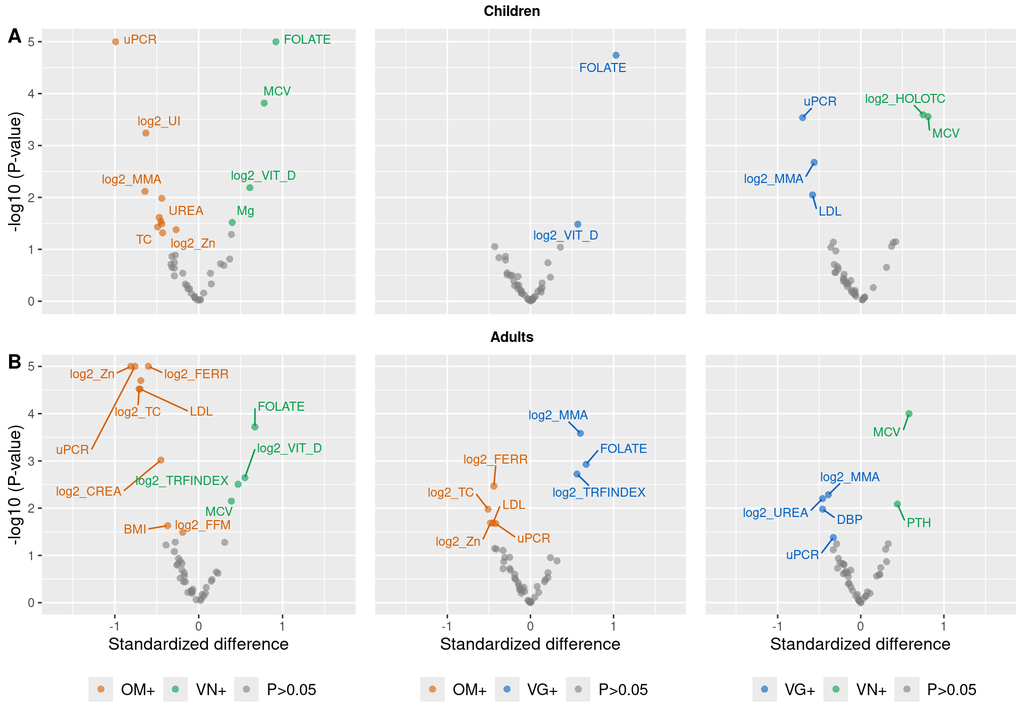

Vulcano plot showing standardized differences between vegan (VN) and omnivores (OM) (*left*), vegetarians (VG) vs OM (*middle*) and VN vs VG (*right*) across clinical outcomes in children (**A**, *top*) and adults (**B**, *bottom*). Estimated effects are based on robust linear mixed-effects models. P-values are not corrected for multiple comparisons to maximize sensitivity for a potential risks

```r
if (file.exists(path) == FALSE) {
  assign(
    plotac,
    ggarrange(
      children_volc,
      adult_volc,
      nrow = 2,
      ncol = 1,
      heights = c(1, 1.2)
    )
  )

  saveRDS(get(plotac), file = path)
  get(plotac)
} else {
  assign(plotac, readRDS(path))
  get(plotac)
}
```

**Open code**

```r
## save svg
plotac <- "fig35"
path <- paste0("gitignore/figures/", plotac, ".svg")

if(!file.exists(path)){
  ggsave(path, get(plotac), device = 'svg', width = 10, height = 7)
}
```

## 2.4 Heatmap matrix

**Open code**

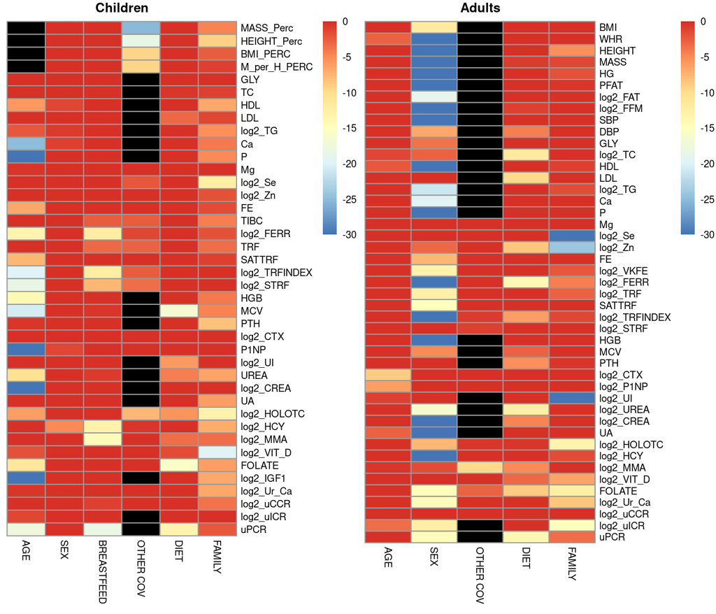

Heatmap showing decrease in the Akaike Information Criterion (AIC) after the addition of a given variable to a mixed-effects model, separately for children (left) and adults (right). The AIC change reflects the impact of the variable on out-of-sample predictive accuracy, with values bounded between -30 (high importance, shown in blue) and 0 (no or negligible importance, shown in red). Black indicates that the variable was not included in the model (e.g., inapplicable supplementation-related variables)

```r
h1 <- heat_map(AIC_child_all, mixef = TRUE, main = 'Children', listt = TRUE)
h2 <- heat_map(AIC_adult, mixef = TRUE, main = 'Adults', listt = TRUE)

grid.arrange(grobs = list(h1$gtable, h2$gtable),
             nrow = 1, ncol = 2)
```

**Open code**

```r
plotac <- 'heatmaps_mixef_combo'
path = paste0('gitignore/figures/', plotac, '.svg')
if(file.exists(path) == FALSE){
  svg(path, width = 7, height = 6)
  grid.arrange(grobs = list(h1$gtable, h2$gtable),
             nrow = 1, ncol = 2)
  dev.off()
}

path <- paste0('gitignore/figures/', plotac, '.pdf')
if (!file.exists(path)) {
  pdf(path, width = 7, height = 6)
  grid.arrange(grobs = list(h1$gtable, h2$gtable),
             nrow = 1, ncol = 2)
  dev.off()
}
```

# 3 Linear-mixed-effects models (non-robust variant)

## 3.1 Children

### 3.1.1 Diet effects

#### 3.1.1.1 Unstandardized effects

**Open code**

```r
diet_child_all <- read.xlsx("gitignore/data/diet_child_all_mixeff_non_robust.xlsx") %>%
  mutate(outcome = clean_outcome_names(outcome)) %>%
  mutate(outcome = case_when(
    outcome == 'FOLAT' ~ 'FOLATE',
    outcome == 'VKFE' ~ 'TIBC',
    outcome == 'Cros' ~ 'CTX',
    outcome == 'log2_Cros' ~ 'log2_CTX',
    outcome == 'VIT_AKTB12' ~ 'HOLOTC',
    outcome == 'log2_VIT_AKTB12' ~ 'log2_HOLOTC',

    outcome == 'log2_aUr_Ca' ~ 'log2_uCa',
    outcome == 'log2_Ca_per_Krea' ~ 'log2_uCCR',
    outcome == 'log2_I_per_Krea' ~ 'log2_uICR',
    outcome == 'P_per_Krea' ~ 'uPCR',
    outcome == 'log2_P_per_Krea' ~ 'log2_uPCR',

    TRUE ~ outcome
  ))

diet_child_all2 <- diet_child_all %>%
  mutate(across(.cols = c(VN_OM_diff, VG_OM_diff, VN_VG_diff), ~ round(.x, 2)))


kableExtra::kable(diet_child_all2,
                caption = "Differences in clinical outcomes (`outcome`) between diet groups in children, estimated using linear mixed-effects models. For each outcome, the table reports the estimated difference (`[...]_diff`), raw p-value (`[...]_P`), and FDR-corrected p-value (`[...]_P_adj`) for multiple comparisons. Comparisons include (A) vegans vs. omnivores (`VN_OM`), (B) vegetarians vs. omnivores (`VG_OM`), and (C) vegans vs. vegetarians (`VN_VG`)."
                ) %>%
  kable_styling("striped",full_width = T) %>%
  add_header_above(c(" " = 2, "(A) VN vs OM" = 3,
                     "(B) VG vs OM" = 3, "(C) VN vs VG" =3)) %>%
  column_spec(1, width_min = '1.5in')
```

Differences in clinical outcomes (`outcome`) between diet groups in children, estimated using linear mixed-effects models. For each outcome, the table reports the estimated difference (`[...]_diff`), raw p-value (`[...]_P`), and FDR-corrected p-value (`[...]_P_adj`) for multiple comparisons. Comparisons include (A) vegans vs. omnivores (`VN_OM`), (B) vegetarians vs. omnivores (`VG_OM`), and (C) vegans vs. vegetarians (`VN_VG`).

| outcome | estimand | (A) VN vs OM VN_OM_diff | (A) VN vs OM VN_OM_P | (A) VN vs OM VN_OM_P_adj | (B) VG vs OM VG_OM_diff | (B) VG vs OM VG_OM_P | (B) VG vs OM VG_OM_P_adj | (C) VN vs VG VN_VG_diff | (C) VN vs VG VN_VG_P | (C) VN vs VG VN_VG_P_adj |
| --- | --- | --- | --- | --- | --- | --- | --- | --- | --- | --- |
| MASS_Perc | mean | -9.03 | 0.1224106 | 0.3139879 | -3.48 | 0.6045777 | 0.9971723 | -5.55 | 0.3552860 | 0.7105720 |
| HEIGHT_Perc | mean | -8.70 | 0.1412946 | 0.3139879 | 0.02 | 0.9971723 | 0.9971723 | -8.72 | 0.1520505 | 0.5320605 |
| BMI_PERC | mean | -2.51 | 0.6471659 | 0.7396182 | -2.93 | 0.6428129 | 0.9971723 | 0.42 | 0.9402838 | 0.9754998 |
| M_per_H_PERC | mean | -3.05 | 0.5724270 | 0.7155338 | -3.39 | 0.5854662 | 0.9971723 | 0.34 | 0.9511123 | 0.9754998 |
| GLY | mean | -0.03 | 0.8000192 | 0.8505275 | 0.02 | 0.9175935 | 0.9971723 | -0.05 | 0.7323108 | 0.8876495 |
| TC | mean | -0.33 | 0.0298531 | 0.1492653 | -0.20 | 0.2682746 | 0.9971723 | -0.14 | 0.4077395 | 0.7766466 |
| HDL | mean | -0.02 | 0.8080011 | 0.8505275 | -0.07 | 0.4158826 | 0.9971723 | 0.06 | 0.5063240 | 0.8623993 |
| LDL | mean | -0.30 | 0.0206126 | 0.1177862 | -0.01 | 0.9715679 | 0.9971723 | -0.30 | 0.0350391 | 0.2803128 |
| log2_TG | mean | 0.00 | 0.9937607 | 0.9937607 | -0.31 | 0.0985864 | 0.9971723 | 0.31 | 0.0737402 | 0.3910889 |
| Ca | mean | -0.01 | 0.6338424 | 0.7396182 | 0.01 | 0.7469291 | 0.9971723 | -0.02 | 0.4273929 | 0.7770781 |
| P | mean | -0.03 | 0.4078436 | 0.5826337 | -0.01 | 0.8957263 | 0.9971723 | -0.02 | 0.5344134 | 0.8623993 |
| Mg | mean | 0.03 | 0.0789224 | 0.2630747 | 0.03 | 0.1282706 | 0.9971723 | 0.00 | 0.9760101 | 0.9760101 |
| log2_Se | mean | -0.15 | 0.2469283 | 0.4489605 | -0.01 | 0.9547127 | 0.9971723 | -0.14 | 0.3180938 | 0.7068751 |
| log2_Zn | mean | -0.10 | 0.1342529 | 0.3139879 | -0.07 | 0.4099470 | 0.9971723 | -0.04 | 0.6354120 | 0.8876495 |
| FE | mean | 1.47 | 0.3367963 | 0.4989575 | -0.61 | 0.7349709 | 0.9971723 | 2.08 | 0.2126189 | 0.5669838 |
| TIBC | mean | -3.77 | 0.0728617 | 0.2630747 | -0.69 | 0.7784954 | 0.9971723 | -3.09 | 0.1729197 | 0.5320605 |
| log2_FERR | mean | -0.23 | 0.2216702 | 0.4489605 | -0.26 | 0.2368430 | 0.9971723 | 0.03 | 0.8756598 | 0.9729554 |
| TRF | mean | -0.16 | 0.0512531 | 0.2050123 | -0.04 | 0.6850538 | 0.9971723 | -0.12 | 0.1712928 | 0.5320605 |
| SATTRF | mean | 3.24 | 0.1341627 | 0.3139879 | -0.01 | 0.9957130 | 0.9971723 | 3.25 | 0.1668047 | 0.5320605 |
| log2_TRFINDEX | mean | 0.03 | 0.7547654 | 0.8386283 | 0.08 | 0.5273110 | 0.9971723 | -0.05 | 0.6925916 | 0.8876495 |
| log2_STRF | mean | -0.04 | 0.4314124 | 0.5950516 | -0.01 | 0.9199755 | 0.9971723 | -0.04 | 0.5389996 | 0.8623993 |
| HGB | mean | 0.96 | 0.6462453 | 0.7396182 | 1.36 | 0.5857707 | 0.9971723 | -0.40 | 0.8603510 | 0.9729554 |
| MCV | mean | 3.18 | 0.0000784 | 0.0013022 | 0.24 | 0.7920987 | 0.9971723 | 2.94 | 0.0006757 | 0.0270265 |
| PTH | mean | 0.32 | 0.3000010 | 0.4653449 | -0.10 | 0.7844067 | 0.9971723 | 0.42 | 0.2112858 | 0.5669838 |
| log2_CTX | mean | 0.06 | 0.4783561 | 0.6255021 | 0.05 | 0.6274840 | 0.9971723 | 0.01 | 0.9083010 | 0.9754998 |
| P1NP | mean | 41.07 | 0.3021109 | 0.4653449 | 55.74 | 0.2460170 | 0.9971723 | -14.67 | 0.7315742 | 0.8876495 |
| log2_UI | mean | -0.96 | 0.0031127 | 0.0311274 | -0.40 | 0.2663855 | 0.9971723 | -0.56 | 0.0782178 | 0.3910889 |
| UREA | mean | -0.57 | 0.0073351 | 0.0586807 | -0.10 | 0.6769059 | 0.9971723 | -0.47 | 0.0425533 | 0.2836889 |
| log2_CREA | mean | -0.10 | 0.0887183 | 0.2729793 | -0.04 | 0.5546942 | 0.9971723 | -0.06 | 0.3507577 | 0.7105720 |
| UA | mean | -7.85 | 0.4847641 | 0.6255021 | -5.10 | 0.7005236 | 0.9971723 | -2.75 | 0.8209653 | 0.9658415 |
| log2_HOLOTC | mean | 0.27 | 0.2420910 | 0.4489605 | -0.30 | 0.1955345 | 0.9971723 | 0.57 | 0.0021550 | 0.0431006 |
| log2_HCY | mean | -0.17 | 0.2379736 | 0.4489605 | 0.02 | 0.8671099 | 0.9971723 | -0.19 | 0.0969613 | 0.4309390 |
| log2_MMA | mean | -0.51 | 0.0464757 | 0.2050123 | -0.02 | 0.9508927 | 0.9971723 | -0.49 | 0.0124297 | 0.1242974 |
| log2_VIT_D | mean | 0.26 | 0.0171848 | 0.1145657 | 0.22 | 0.0893232 | 0.9971723 | 0.04 | 0.7185425 | 0.8876495 |
| FOLATE | mean | 3.94 | 0.0000928 | 0.0013022 | 4.49 | 0.0001577 | 0.0063064 | -0.55 | 0.6002629 | 0.8876495 |
| log2_IGF1 | mean | -0.14 | 0.3024742 | 0.4653449 | 0.02 | 0.9130673 | 0.9971723 | -0.16 | 0.2940446 | 0.6918698 |
| log2_Ur_Ca | mean | -0.39 | 0.2951999 | 0.4653449 | 0.04 | 0.9254037 | 0.9971723 | -0.43 | 0.2455164 | 0.6137910 |
| log2_uCCR | mean | 0.02 | 0.9638138 | 0.9885270 | 0.15 | 0.7138363 | 0.9971723 | -0.13 | 0.7103345 | 0.8876495 |
| log2_uICR | mean | -0.47 | 0.1131462 | 0.3139879 | -0.33 | 0.3135735 | 0.9971723 | -0.14 | 0.6416148 | 0.8876495 |
| uPCR | mean | -1.88 | 0.0000977 | 0.0013022 | -0.53 | 0.3183705 | 0.9971723 | -1.35 | 0.0041575 | 0.0554332 |

#### 3.1.1.2 Standardized effects by 1SD

**Open code**

```r
meds <- diet_child_all %>% filter(estimand == "mean")

ids <- nrow(meds)
sds <- vector("double", ids)
sds
##  [1] 0 0 0 0 0 0 0 0 0 0 0 0 0 0 0 0 0 0 0 0 0 0 0 0 0 0 0 0 0 0 0 0 0 0 0 0 0 0
## [39] 0 0

before_outcome_col <- which(colnames(dat_child_all) == 'aMASS_Perc')-1

sds <- vector("double", ids)

for(i in 1:ids){
  sds[i] <- ifelse(grepl("log2", diet_child_all[(i), 'outcome']),
                   sd(log2(dat_child_all[,(i + before_outcome_col)]), na.rm = TRUE),
                   sd(dat_child_all[,(i + before_outcome_col)], na.rm = TRUE))
}


diet_child_all_Z <- diet_child_all %>%
  mutate(SD = sds) %>%
  mutate(
    VN_OM_diff = VN_OM_diff/SD,
    VG_OM_diff = VG_OM_diff/SD,
    VN_VG_diff = VN_VG_diff/SD) %>%
  select(-c(SD)) %>%
  mutate(across(.cols = c(VG_OM_diff, VN_OM_diff, VN_VG_diff), ~ round(.x, 2)))


kbl(diet_child_all_Z, caption =
      "Standardized differences in clinical outcomes (`outcome`) between diet groups in children, estimated using linear mixed-effects models. For each outcome, the table reports the estimated difference (`[...]_diff`), raw p-value (`[...]_P`), and FDR-corrected p-value (`[...]_P_adj`) for multiple comparisons. Comparisons include (A) vegans vs. omnivores (`VN_OM`), (B) vegetarians vs. omnivores (`VG_OM`), and (C) vegans vs. vegetarians (`VN_VG`).") %>%
  kable_styling("striped",full_width = T) %>%
  add_header_above(c(" " = 2, "(A) VN vs OM" = 3,
                     "(B) VG vs OM" = 3, "(C) VN vs VG" =3)) %>%
  column_spec(1, width_min = '1.5in')
```

Standardized differences in clinical outcomes (`outcome`) between diet groups in children, estimated using linear mixed-effects models. For each outcome, the table reports the estimated difference (`[...]_diff`), raw p-value (`[...]_P`), and FDR-corrected p-value (`[...]_P_adj`) for multiple comparisons. Comparisons include (A) vegans vs. omnivores (`VN_OM`), (B) vegetarians vs. omnivores (`VG_OM`), and (C) vegans vs. vegetarians (`VN_VG`).

| outcome | estimand | (A) VN vs OM VN_OM_diff | (A) VN vs OM VN_OM_P | (A) VN vs OM VN_OM_P_adj | (B) VG vs OM VG_OM_diff | (B) VG vs OM VG_OM_P | (B) VG vs OM VG_OM_P_adj | (C) VN vs VG VN_VG_diff | (C) VN vs VG VN_VG_P | (C) VN vs VG VN_VG_P_adj |
| --- | --- | --- | --- | --- | --- | --- | --- | --- | --- | --- |
| MASS_Perc | mean | -0.31 | 0.1224106 | 0.3139879 | -0.12 | 0.6045777 | 0.9971723 | -0.19 | 0.3552860 | 0.7105720 |
| HEIGHT_Perc | mean | -0.32 | 0.1412946 | 0.3139879 | 0.00 | 0.9971723 | 0.9971723 | -0.32 | 0.1520505 | 0.5320605 |
| BMI_PERC | mean | -0.10 | 0.6471659 | 0.7396182 | -0.12 | 0.6428129 | 0.9971723 | 0.02 | 0.9402838 | 0.9754998 |
| M_per_H_PERC | mean | -0.12 | 0.5724270 | 0.7155338 | -0.14 | 0.5854662 | 0.9971723 | 0.01 | 0.9511123 | 0.9754998 |
| GLY | mean | -0.06 | 0.8000192 | 0.8505275 | 0.03 | 0.9175935 | 0.9971723 | -0.08 | 0.7323108 | 0.8876495 |
| TC | mean | -0.50 | 0.0298531 | 0.1492653 | -0.30 | 0.2682746 | 0.9971723 | -0.21 | 0.4077395 | 0.7766466 |
| HDL | mean | -0.06 | 0.8080011 | 0.8505275 | -0.22 | 0.4158826 | 0.9971723 | 0.17 | 0.5063240 | 0.8623993 |
| LDL | mean | -0.54 | 0.0206126 | 0.1177862 | -0.01 | 0.9715679 | 0.9971723 | -0.53 | 0.0350391 | 0.2803128 |
| log2_TG | mean | 0.00 | 0.9937607 | 0.9937607 | -0.44 | 0.0985864 | 0.9971723 | 0.43 | 0.0737402 | 0.3910889 |
| Ca | mean | -0.09 | 0.6338424 | 0.7396182 | 0.07 | 0.7469291 | 0.9971723 | -0.17 | 0.4273929 | 0.7770781 |
| P | mean | -0.16 | 0.4078436 | 0.5826337 | -0.03 | 0.8957263 | 0.9971723 | -0.13 | 0.5344134 | 0.8623993 |
| Mg | mean | 0.38 | 0.0789224 | 0.2630747 | 0.39 | 0.1282706 | 0.9971723 | -0.01 | 0.9760101 | 0.9760101 |
| log2_Se | mean | -0.29 | 0.2469283 | 0.4489605 | -0.02 | 0.9547127 | 0.9971723 | -0.27 | 0.3180938 | 0.7068751 |
| log2_Zn | mean | -0.36 | 0.1342529 | 0.3139879 | -0.23 | 0.4099470 | 0.9971723 | -0.13 | 0.6354120 | 0.8876495 |
| FE | mean | 0.21 | 0.3367963 | 0.4989575 | -0.09 | 0.7349709 | 0.9971723 | 0.30 | 0.2126189 | 0.5669838 |
| TIBC | mean | -0.41 | 0.0728617 | 0.2630747 | -0.08 | 0.7784954 | 0.9971723 | -0.34 | 0.1729197 | 0.5320605 |
| log2_FERR | mean | -0.26 | 0.2216702 | 0.4489605 | -0.29 | 0.2368430 | 0.9971723 | 0.04 | 0.8756598 | 0.9729554 |
| TRF | mean | -0.45 | 0.0512531 | 0.2050123 | -0.11 | 0.6850538 | 0.9971723 | -0.34 | 0.1712928 | 0.5320605 |
| SATTRF | mean | 0.33 | 0.1341627 | 0.3139879 | 0.00 | 0.9957130 | 0.9971723 | 0.33 | 0.1668047 | 0.5320605 |
| log2_TRFINDEX | mean | 0.06 | 0.7547654 | 0.8386283 | 0.15 | 0.5273110 | 0.9971723 | -0.09 | 0.6925916 | 0.8876495 |
| log2_STRF | mean | -0.16 | 0.4314124 | 0.5950516 | -0.02 | 0.9199755 | 0.9971723 | -0.14 | 0.5389996 | 0.8623993 |
| HGB | mean | 0.10 | 0.6462453 | 0.7396182 | 0.14 | 0.5857707 | 0.9971723 | -0.04 | 0.8603510 | 0.9729554 |
| MCV | mean | 0.83 | 0.0000784 | 0.0013022 | 0.06 | 0.7920987 | 0.9971723 | 0.77 | 0.0006757 | 0.0270265 |
| PTH | mean | 0.26 | 0.3000010 | 0.4653449 | -0.08 | 0.7844067 | 0.9971723 | 0.34 | 0.2112858 | 0.5669838 |
| log2_CTX | mean | 0.16 | 0.4783561 | 0.6255021 | 0.13 | 0.6274840 | 0.9971723 | 0.03 | 0.9083010 | 0.9754998 |
| P1NP | mean | 0.14 | 0.3021109 | 0.4653449 | 0.19 | 0.2460170 | 0.9971723 | -0.05 | 0.7315742 | 0.8876495 |
| log2_UI | mean | -0.77 | 0.0031127 | 0.0311274 | -0.32 | 0.2663855 | 0.9971723 | -0.45 | 0.0782178 | 0.3910889 |
| UREA | mean | -0.46 | 0.0073351 | 0.0586807 | -0.08 | 0.6769059 | 0.9971723 | -0.38 | 0.0425533 | 0.2836889 |
| log2_CREA | mean | -0.24 | 0.0887183 | 0.2729793 | -0.10 | 0.5546942 | 0.9971723 | -0.14 | 0.3507577 | 0.7105720 |
| UA | mean | -0.16 | 0.4847641 | 0.6255021 | -0.11 | 0.7005236 | 0.9971723 | -0.06 | 0.8209653 | 0.9658415 |
| log2_HOLOTC | mean | 0.33 | 0.2420910 | 0.4489605 | -0.37 | 0.1955345 | 0.9971723 | 0.70 | 0.0021550 | 0.0431006 |
| log2_HCY | mean | -0.37 | 0.2379736 | 0.4489605 | 0.05 | 0.8671099 | 0.9971723 | -0.42 | 0.0969613 | 0.4309390 |
| log2_MMA | mean | -0.56 | 0.0464757 | 0.2050123 | -0.02 | 0.9508927 | 0.9971723 | -0.54 | 0.0124297 | 0.1242974 |
| log2_VIT_D | mean | 0.55 | 0.0171848 | 0.1145657 | 0.47 | 0.0893232 | 0.9971723 | 0.08 | 0.7185425 | 0.8876495 |
| FOLATE | mean | 0.85 | 0.0000928 | 0.0013022 | 0.96 | 0.0001577 | 0.0063064 | -0.12 | 0.6002629 | 0.8876495 |
| log2_IGF1 | mean | -0.17 | 0.3024742 | 0.4653449 | 0.02 | 0.9130673 | 0.9971723 | -0.20 | 0.2940446 | 0.6918698 |
| log2_Ur_Ca | mean | -0.27 | 0.2951999 | 0.4653449 | 0.03 | 0.9254037 | 0.9971723 | -0.30 | 0.2455164 | 0.6137910 |
| log2_uCCR | mean | 0.01 | 0.9638138 | 0.9885270 | 0.10 | 0.7138363 | 0.9971723 | -0.09 | 0.7103345 | 0.8876495 |
| log2_uICR | mean | -0.36 | 0.1131462 | 0.3139879 | -0.26 | 0.3135735 | 0.9971723 | -0.11 | 0.6416148 | 0.8876495 |
| uPCR | mean | -0.88 | 0.0000977 | 0.0013022 | -0.25 | 0.3183705 | 0.9971723 | -0.63 | 0.0041575 | 0.0554332 |

#### 3.1.1.3 Vulcano plots

VN vs OM

**Open code**

```r
plotac <- "fig19_nr"

path <- paste0("gitignore/figures/", plotac, ".rds")

if (file.exists(path) == FALSE) {
  assign(plotac, diet_child_all_Z %>%
    filter(estimand != "log(OR)") %>%
    mutate(
      pv_adj = VN_OM_P_adj,
      pv_raw = VN_OM_P,
      b_coe = VN_OM_diff
    ) %>%
    mutate(pv_raw = if_else(pv_raw < 1e-5, 1e-5, pv_raw)) %>%
    mutate(
      m_ylab = -log10(pv_raw),
      m_xlab = b_coe,
      rescat = if_else(
        pv_raw >= 0.05,
        "P>0.05",
        if_else(
          b_coe > 0,
          "VN+",
          "OM+"
        )
      )
    ) %>%
    mutate(
      rescat = factor(rescat,
        levels = c("OM+", "VN+", "P>0.05")
      ),
      meta_labels = if_else(pv_raw < 0.05, outcome, "")
    ) %>%
    ggplot(aes(
      x = b_coe,
      y = m_ylab,
      color = rescat,
      alpha = rescat,
      label = meta_labels
    )) +
    geom_point(size = 2, shape = 16, alpha = 0.6) +
    geom_text_repel(
      aes(
        x = m_xlab,
        y = m_ylab
      ),
      show.legend = FALSE,
      alpha = 1,
      box.padding = 0.3,
      size = 3.1,
      seed = 17
    ) +
    labs(x = "Standardized difference", y = "-log10 (P-value)") +
    scale_color_manual(values = color_map, name = "") +
    ggtitle("VN vs. OM, all children") +
    theme(
      legend.text = element_text(size = 11),
      axis.title = element_text(size = 12)
    ) +
    coord_cartesian(
      ylim = c(0, 5),
      xlim = c(-1.7, 1.7)
    ))

  saveRDS(get(plotac), file = path)
} else {
  assign(plotac, readRDS(path))
}
```

VG vs OM

**Open code**

```r
plotac <- "fig20_nr"

path <- paste0("gitignore/figures/", plotac, ".rds")

if (file.exists(path) == FALSE) {
  assign(plotac, diet_child_all_Z %>%
    filter(estimand != "log(OR)") %>%
    mutate(VG_OM_P = if_else(VG_OM_P < 1e-5, 1e-5, VG_OM_P)) %>%
    mutate(
      pv_adj = VG_OM_P_adj,
      pv_raw = VG_OM_P,
      b_coe = VG_OM_diff
    ) %>%
    mutate(pv_raw = if_else(pv_raw < 1e-5, 1e-5, pv_raw)) %>%
    mutate(
      m_ylab = -log10(pv_raw),
      m_xlab = b_coe,
      rescat = if_else(
        pv_raw >= 0.05,
        "P>0.05",
        if_else(
          b_coe > 0,
          "VG+",
          "OM+"
        )
      )
    ) %>%
    mutate(
      rescat = factor(rescat,
        levels = c("OM+", "VG+", "P>0.05")
      ),
      meta_labels = if_else(pv_raw < 0.05, outcome, "")
    ) %>%
    ggplot(aes(
      x = b_coe,
      y = m_ylab,
      color = rescat,
      alpha = rescat,
      label = meta_labels
    )) +
    geom_point(size = 2, shape = 16, alpha = 0.6) +
    geom_text_repel(
      aes(
        x = m_xlab,
        y = m_ylab
      ),
      show.legend = FALSE,
      alpha = 1,
      box.padding = 0.3,
      size = 3.1,
      seed = 17
    ) +
    labs(x = "Standardized difference", y = "-log10 (P-value)") +
    scale_color_manual(values = color_map, name = "") +
    ggtitle("VG vs. OM, all children") +
    theme(
      legend.text = element_text(size = 11),
      axis.title = element_text(size = 12)
    ) +
    coord_cartesian(
      ylim = c(0, 5),
      xlim = c(-1.7, 1.7)
    ))

  saveRDS(get(plotac), file = path)
} else {
  assign(plotac, readRDS(path))
}
```

VN vs VG

**Open code**

```r
plotac <- "fig21_nr"

path <- paste0("gitignore/figures/", plotac, ".rds")

if (file.exists(path) == FALSE) {
  assign(plotac, diet_child_all_Z %>%
    filter(estimand != "log(OR)") %>%

    mutate(
      pv_adj = VN_VG_P_adj,
      pv_raw = VN_VG_P,
      b_coe = VN_VG_diff
    ) %>%
    mutate(pv_raw = if_else(pv_raw < 1e-5, 1e-5, pv_raw)) %>%
    mutate(
      m_ylab = -log10(pv_raw),
      m_xlab = b_coe,
      rescat = if_else(
        pv_raw >= 0.05,
        "P>0.05",
        if_else(
          b_coe > 0,
          "VN+",
          "VG+"
        )
      )
    ) %>%
    mutate(
      rescat = factor(rescat,
        levels = c(
          "VG+",
          "VN+",
          "P>0.05"
        )
      ),
      meta_labels = if_else(pv_raw < 0.05, outcome, "")
    ) %>%
    ggplot(aes(
      x = b_coe,
      y = m_ylab,
      color = rescat,
      alpha = rescat,
      label = meta_labels
    )) +
    geom_point(size = 2, shape = 16, alpha = 0.6) +
    geom_text_repel(
      aes(
        x = m_xlab,
        y = m_ylab
      ),
      show.legend = FALSE,
      alpha = 1,
      box.padding = 0.5,
      size = 3.1,
      seed = 16
    ) +
    labs(
      x = "Standardized difference",
      y = "-log10 (P-value)"
    ) +
    scale_color_manual(values = color_map, name = "") +
    ggtitle("VN vs VG, all children") +
    theme(
      legend.text = element_text(size = 11),
      axis.title = element_text(size = 12)
    ) +
    coord_cartesian(
      ylim = c(0, 5),
      xlim = c(-1.7, 1.7)
    ))

  saveRDS(get(plotac), file = path)
} else {
  assign(plotac, readRDS(path))
}
```

## 3.2 Adults

### 3.2.1 Diet effects

#### 3.2.1.1 Unstandardized effects

**Open code**

```r
diet_adult <- read.xlsx("gitignore/data/diet_adult_non_robust_mixeff_non_robust.xlsx") %>%
  mutate(outcome = clean_outcome_names(outcome)) %>%
  mutate(outcome = case_when(
    outcome == "FOLAT" ~ "FOLATE",
    outcome == "log2_VKFE" ~ "log2_TIBC",
    outcome == "Cros" ~ "CTX",
    outcome == "log2_Cros" ~ "log2_CTX",
    outcome == "VIT_AKTB12" ~ "HOLOTC",
    outcome == "log2_VIT_AKTB12" ~ "log2_HOLOTC",

    outcome == 'log2_aUr_Ca' ~ 'log2_uCa',
    outcome == 'log2_Ca_per_Krea' ~ 'log2_uCCR',
    outcome == 'log2_I_per_Krea' ~ 'log2_uICR',
    outcome == 'P_per_Krea' ~ 'uPCR',
    outcome == 'log2_P_per_Krea' ~ 'log2_uPCR',
    TRUE ~ outcome
  ))

diet_adult2 <- diet_adult %>%
  mutate(across(.cols = c(VN_OM_diff, VG_OM_diff, VN_VG_diff), ~ round(.x, 2)))

kbl(diet_adult2,
  caption =
    "Differences in clinical outcomes (`outcome`) between diet groups in adults, estimated using linear mixed-effects models. For each outcome, the table reports the estimated difference (`[...]_diff`), raw p-value (`[...]_P`), and FDR-corrected p-value (`[...]_P_adj`) for multiple comparisons. Comparisons include (A) vegans vs. omnivores (`VN_OM`), (B) vegetarians vs. omnivores (`VG_OM`), and (C) vegans vs. vegetarians (`VN_VG`)."
) %>%
  kable_styling("striped", full_width = T) %>%
  add_header_above(c(
    " " = 2, "(A) VN vs OM" = 3,
    "(B) VG vs OM" = 3, "(C) VN vs VG" = 3
  )) %>%
  column_spec(1, width_min = "1.5in")
```

Differences in clinical outcomes (`outcome`) between diet groups in adults, estimated using linear mixed-effects models. For each outcome, the table reports the estimated difference (`[...]_diff`), raw p-value (`[...]_P`), and FDR-corrected p-value (`[...]_P_adj`) for multiple comparisons. Comparisons include (A) vegans vs. omnivores (`VN_OM`), (B) vegetarians vs. omnivores (`VG_OM`), and (C) vegans vs. vegetarians (`VN_VG`).

| outcome | estimand | (A) VN vs OM VN_OM_diff | (A) VN vs OM VN_OM_P | (A) VN vs OM VN_OM_P_adj | (B) VG vs OM VG_OM_diff | (B) VG vs OM VG_OM_P | (B) VG vs OM VG_OM_P_adj | (C) VN vs VG VN_VG_diff | (C) VN vs VG VN_VG_P | (C) VN vs VG VN_VG_P_adj |
| --- | --- | --- | --- | --- | --- | --- | --- | --- | --- | --- |
| BMI | mean | -1.27 | 0.05644 | 0.17544 | -0.38 | 0.62265 | 0.81153 | -0.90 | 0.19057 | 0.42652 |
| WHR | mean | -0.02 | 0.12747 | 0.27232 | 0.00 | 0.94638 | 0.98844 | -0.02 | 0.12097 | 0.42652 |
| HEIGHT | mean | -0.01 | 0.71233 | 0.77859 | 0.01 | 0.62498 | 0.81153 | -0.01 | 0.36602 | 0.57343 |
| MASS | mean | -4.45 | 0.04604 | 0.15455 | -0.65 | 0.79770 | 0.89062 | -3.80 | 0.09800 | 0.42652 |
| HG | mean | 0.83 | 0.54439 | 0.62405 | 1.52 | 0.33940 | 0.79760 | -0.68 | 0.62794 | 0.77666 |
| PFAT | mean | -1.60 | 0.20782 | 0.34506 | 0.02 | 0.98770 | 0.99349 | -1.63 | 0.21572 | 0.44534 |
| log2_FAT | mean | -0.22 | 0.08157 | 0.19170 | -0.05 | 0.74859 | 0.87960 | -0.17 | 0.18161 | 0.42652 |
| log2_FFM | mean | -0.06 | 0.03110 | 0.11687 | -0.02 | 0.58978 | 0.81153 | -0.04 | 0.13328 | 0.42652 |
| SBP | mean | -5.01 | 0.06837 | 0.18663 | -3.55 | 0.26104 | 0.72113 | -1.46 | 0.60348 | 0.77666 |
| DBP | mean | -2.64 | 0.11151 | 0.24958 | 2.24 | 0.24169 | 0.72113 | -4.88 | 0.00498 | 0.08969 |
| GLY | mean | -0.08 | 0.36725 | 0.49317 | 0.02 | 0.81483 | 0.89062 | -0.11 | 0.25703 | 0.46464 |
| log2_TC | mean | -0.20 | 0.00010 | 0.00151 | -0.13 | 0.02523 | 0.23715 | -0.07 | 0.16557 | 0.42652 |
| HDL | mean | -0.04 | 0.56114 | 0.62794 | -0.08 | 0.30203 | 0.74713 | 0.04 | 0.55223 | 0.77666 |
| LDL | mean | -0.48 | 0.00027 | 0.00250 | -0.24 | 0.10186 | 0.51319 | -0.24 | 0.07216 | 0.42652 |
| log2_TG | mean | -0.15 | 0.24651 | 0.37498 | -0.10 | 0.53313 | 0.81153 | -0.06 | 0.66848 | 0.78546 |
| Ca | mean | 0.00 | 0.76142 | 0.81334 | 0.01 | 0.59798 | 0.81153 | 0.00 | 0.76706 | 0.85837 |
| P | mean | -0.03 | 0.26930 | 0.38813 | 0.00 | 0.99349 | 0.99349 | -0.03 | 0.28863 | 0.50243 |
| Mg | mean | -0.01 | 0.51192 | 0.60897 | -0.01 | 0.38038 | 0.81153 | 0.00 | 0.73404 | 0.84146 |
| log2_Se | mean | -0.14 | 0.20119 | 0.34506 | -0.16 | 0.20654 | 0.72113 | 0.02 | 0.85731 | 0.87595 |
| log2_Zn | mean | -0.20 | 0.00052 | 0.00404 | -0.10 | 0.12011 | 0.51319 | -0.10 | 0.08854 | 0.42652 |
| FE | mean | 0.19 | 0.89833 | 0.93826 | -1.30 | 0.44987 | 0.81153 | 1.49 | 0.33540 | 0.54357 |
| log2_TIBC | mean | 0.05 | 0.20427 | 0.34506 | 0.03 | 0.50558 | 0.81153 | 0.02 | 0.62114 | 0.77666 |
| log2_FERR | mean | -0.86 | 0.00003 | 0.00107 | -0.58 | 0.01227 | 0.14415 | -0.28 | 0.17286 | 0.42652 |
| log2_TRF | mean | 0.05 | 0.21291 | 0.34506 | 0.03 | 0.52717 | 0.81153 | 0.02 | 0.61144 | 0.77666 |
| SATTRF | mean | 0.00 | 0.99979 | 0.99979 | -2.03 | 0.45260 | 0.81153 | 2.03 | 0.40363 | 0.61195 |
| log2_TRFINDEX | mean | 0.27 | 0.00385 | 0.02011 | 0.28 | 0.00898 | 0.14061 | -0.01 | 0.91768 | 0.91768 |
| log2_STRF | mean | 0.09 | 0.24733 | 0.37498 | 0.11 | 0.22009 | 0.72113 | -0.02 | 0.80476 | 0.85963 |
| HGB | mean | -2.40 | 0.31410 | 0.43420 | -1.31 | 0.63448 | 0.81153 | -1.09 | 0.65602 | 0.78546 |
| MCV | mean | 1.05 | 0.16119 | 0.31567 | -0.94 | 0.27485 | 0.72113 | 1.98 | 0.01093 | 0.12840 |
| PTH | mean | 0.48 | 0.03233 | 0.11687 | -0.17 | 0.51452 | 0.81153 | 0.65 | 0.00553 | 0.08969 |
| log2_CTX | mean | 0.00 | 0.99695 | 0.99979 | -0.15 | 0.38453 | 0.81153 | 0.15 | 0.31117 | 0.52232 |
| log2_P1NP | mean | 0.15 | 0.16018 | 0.31567 | 0.02 | 0.84126 | 0.89862 | 0.13 | 0.22741 | 0.44534 |
| log2_UI | mean | -0.49 | 0.19890 | 0.34506 | -0.72 | 0.11270 | 0.51319 | 0.22 | 0.56837 | 0.77666 |
| log2_UREA | mean | -0.28 | 0.00022 | 0.00250 | -0.07 | 0.42385 | 0.81153 | -0.21 | 0.00573 | 0.08969 |
| log2_CREA | mean | -0.13 | 0.00349 | 0.02011 | -0.06 | 0.20547 | 0.72113 | -0.07 | 0.14378 | 0.42652 |
| UA | mean | -7.83 | 0.45945 | 0.56826 | -5.85 | 0.63171 | 0.81153 | -1.98 | 0.85613 | 0.87595 |
| log2_HOLOTC | mean | -0.15 | 0.41789 | 0.54558 | -0.37 | 0.04226 | 0.33106 | 0.22 | 0.15627 | 0.42652 |
| log2_HCY | mean | -0.09 | 0.43623 | 0.55413 | 0.05 | 0.63887 | 0.81153 | -0.15 | 0.15720 | 0.42652 |
| log2_MMA | mean | 0.30 | 0.05973 | 0.17544 | 0.46 | 0.00308 | 0.14061 | -0.16 | 0.22122 | 0.44534 |
| log2_VIT_D | mean | 0.24 | 0.00857 | 0.04027 | 0.11 | 0.27618 | 0.72113 | 0.13 | 0.15364 | 0.42652 |
| FOLATE | mean | 3.29 | 0.00070 | 0.00468 | 3.03 | 0.00622 | 0.14061 | 0.26 | 0.79120 | 0.85963 |
| log2_Ur_Ca | mean | -0.48 | 0.07264 | 0.18663 | -0.11 | 0.70675 | 0.85960 | -0.37 | 0.17532 | 0.42652 |
| log2_uCCR | mean | -0.22 | 0.27251 | 0.38813 | -0.08 | 0.71328 | 0.85960 | -0.14 | 0.49930 | 0.73335 |
| log2_uICR | mean | -0.23 | 0.51827 | 0.60897 | -0.67 | 0.11644 | 0.51319 | 0.43 | 0.24063 | 0.45239 |
| uPCR | mean | -0.65 | 0.00005 | 0.00107 | -0.32 | 0.06937 | 0.46575 | -0.33 | 0.03866 | 0.36338 |
| AL_adult | log(OR) | -1.95 | 0.01704 | 0.07280 | -0.61 | 0.44626 | 0.81153 | -1.34 | 0.08705 | 0.42652 |
| BREAKS | log(OR) | -0.69 | 0.07545 | 0.18663 | -0.12 | 0.78594 | 0.89062 | -0.57 | 0.15320 | 0.42652 |

#### 3.2.1.2 Standardized effects by 1SD

**Open code**

```r
meds <- diet_adult %>% filter(estimand == "mean")

ids <- nrow(meds)
sds <- vector("double", ids)
sds
##  [1] 0 0 0 0 0 0 0 0 0 0 0 0 0 0 0 0 0 0 0 0 0 0 0 0 0 0 0 0 0 0 0 0 0 0 0 0 0 0
## [39] 0 0 0 0 0 0 0

before_outcome_col <- which(colnames(dat_adult) == 'aBMI')-1

for (i in 1:ids) {
  sds[i] <- ifelse(grepl("log2", diet_adult[(i), 1]),
    sd(log2(dat_adult[, (i + before_outcome_col)]), na.rm = TRUE),
    sd(     dat_adult[, (i + before_outcome_col)] , na.rm = TRUE)
  )
}

sds[(ids+1) : (ids+2)] <- 1

diet_adult_Z <- diet_adult %>%
  mutate(SD = sds) %>%
  mutate(
    VN_OM_diff = VN_OM_diff / SD,
    VG_OM_diff = VG_OM_diff / SD,
    VN_VG_diff = VN_VG_diff / SD
  ) %>%
  select(-SD) %>%
  mutate(VG_OM_P = if_else(VG_OM_P < 1e-5, 1e-5, VG_OM_P)) %>%
  mutate(across(.cols = c(VN_OM_diff, VG_OM_diff, VN_VG_diff), ~ round(.x, 2)))


kbl(diet_adult_Z,
  caption =
    "Standardized differences in clinical outcomes (`outcome`) between diet groups in adults, estimated using linear mixed-effects models. For each outcome, the table reports the estimated difference (`[...]_diff`), raw p-value (`[...]_P`), and FDR-corrected p-value (`[...]_P_adj`) for multiple comparisons. Comparisons include (A) vegans vs. omnivores (`VN_OM`), (B) vegetarians vs. omnivores (`VG_OM`), and (C) vegans vs. vegetarians (`VN_VG`)."
) %>%
  kable_styling("striped", full_width = T) %>%
  add_header_above(c(
    " " = 2, "(A) VN vs OM" = 3,
    "(B) VG vs OM" = 3, "(C) VN vs VG" = 3
  )) %>%
  column_spec(1, width_min = "1.5in")
```

Standardized differences in clinical outcomes (`outcome`) between diet groups in adults, estimated using linear mixed-effects models. For each outcome, the table reports the estimated difference (`[...]_diff`), raw p-value (`[...]_P`), and FDR-corrected p-value (`[...]_P_adj`) for multiple comparisons. Comparisons include (A) vegans vs. omnivores (`VN_OM`), (B) vegetarians vs. omnivores (`VG_OM`), and (C) vegans vs. vegetarians (`VN_VG`).

| outcome | estimand | (A) VN vs OM VN_OM_diff | (A) VN vs OM VN_OM_P | (A) VN vs OM VN_OM_P_adj | (B) VG vs OM VG_OM_diff | (B) VG vs OM VG_OM_P | (B) VG vs OM VG_OM_P_adj | (C) VN vs VG VN_VG_diff | (C) VN vs VG VN_VG_P | (C) VN vs VG VN_VG_P_adj |
| --- | --- | --- | --- | --- | --- | --- | --- | --- | --- | --- |
| BMI | mean | -0.35 | 0.05644 | 0.17544 | -0.10 | 0.62265 | 0.81153 | -0.25 | 0.19057 | 0.42652 |
| WHR | mean | -0.22 | 0.12747 | 0.27232 | 0.01 | 0.94638 | 0.98844 | -0.23 | 0.12097 | 0.42652 |
| HEIGHT | mean | -0.06 | 0.71233 | 0.77859 | 0.09 | 0.62498 | 0.81153 | -0.14 | 0.36602 | 0.57343 |
| MASS | mean | -0.32 | 0.04604 | 0.15455 | -0.05 | 0.79770 | 0.89062 | -0.27 | 0.09800 | 0.42652 |
| HG | mean | 0.06 | 0.54439 | 0.62405 | 0.12 | 0.33940 | 0.79760 | -0.05 | 0.62794 | 0.77666 |
| PFAT | mean | -0.19 | 0.20782 | 0.34506 | 0.00 | 0.98770 | 0.99349 | -0.20 | 0.21572 | 0.44534 |
| log2_FAT | mean | -0.32 | 0.08157 | 0.19170 | -0.07 | 0.74859 | 0.87960 | -0.25 | 0.18161 | 0.42652 |
| log2_FFM | mean | -0.20 | 0.03110 | 0.11687 | -0.06 | 0.58978 | 0.81153 | -0.14 | 0.13328 | 0.42652 |
| SBP | mean | -0.30 | 0.06837 | 0.18663 | -0.21 | 0.26104 | 0.72113 | -0.09 | 0.60348 | 0.77666 |
| DBP | mean | -0.28 | 0.11151 | 0.24958 | 0.24 | 0.24169 | 0.72113 | -0.53 | 0.00498 | 0.08969 |
| GLY | mean | -0.17 | 0.36725 | 0.49317 | 0.05 | 0.81483 | 0.89062 | -0.22 | 0.25703 | 0.46464 |
| log2_TC | mean | -0.70 | 0.00010 | 0.00151 | -0.45 | 0.02523 | 0.23715 | -0.25 | 0.16557 | 0.42652 |
| HDL | mean | -0.10 | 0.56114 | 0.62794 | -0.20 | 0.30203 | 0.74713 | 0.10 | 0.55223 | 0.77666 |
| LDL | mean | -0.68 | 0.00027 | 0.00250 | -0.34 | 0.10186 | 0.51319 | -0.34 | 0.07216 | 0.42652 |
| log2_TG | mean | -0.22 | 0.24651 | 0.37498 | -0.13 | 0.53313 | 0.81153 | -0.08 | 0.66848 | 0.78546 |
| Ca | mean | 0.06 | 0.76142 | 0.81334 | 0.11 | 0.59798 | 0.81153 | -0.06 | 0.76706 | 0.85837 |
| P | mean | -0.18 | 0.26930 | 0.38813 | 0.00 | 0.99349 | 0.99349 | -0.18 | 0.28863 | 0.50243 |
| Mg | mean | -0.12 | 0.51192 | 0.60897 | -0.18 | 0.38038 | 0.81153 | 0.06 | 0.73404 | 0.84146 |
| log2_Se | mean | -0.29 | 0.20119 | 0.34506 | -0.33 | 0.20654 | 0.72113 | 0.04 | 0.85731 | 0.87595 |
| log2_Zn | mean | -0.74 | 0.00052 | 0.00404 | -0.38 | 0.12011 | 0.51319 | -0.37 | 0.08854 | 0.42652 |
| FE | mean | 0.02 | 0.89833 | 0.93826 | -0.16 | 0.44987 | 0.81153 | 0.19 | 0.33540 | 0.54357 |
| log2_TIBC | mean | 0.25 | 0.20427 | 0.34506 | 0.15 | 0.50558 | 0.81153 | 0.10 | 0.62114 | 0.77666 |
| log2_FERR | mean | -0.69 | 0.00003 | 0.00107 | -0.47 | 0.01227 | 0.14415 | -0.23 | 0.17286 | 0.42652 |
| log2_TRF | mean | 0.24 | 0.21291 | 0.34506 | 0.14 | 0.52717 | 0.81153 | 0.10 | 0.61144 | 0.77666 |
| SATTRF | mean | 0.00 | 0.99979 | 0.99979 | -0.16 | 0.45260 | 0.81153 | 0.16 | 0.40363 | 0.61195 |
| log2_TRFINDEX | mean | 0.51 | 0.00385 | 0.02011 | 0.53 | 0.00898 | 0.14061 | -0.02 | 0.91768 | 0.91768 |
| log2_STRF | mean | 0.21 | 0.24733 | 0.37498 | 0.26 | 0.22009 | 0.72113 | -0.05 | 0.80476 | 0.85963 |
| HGB | mean | -0.16 | 0.31410 | 0.43420 | -0.09 | 0.63448 | 0.81153 | -0.07 | 0.65602 | 0.78546 |
| MCV | mean | 0.25 | 0.16119 | 0.31567 | -0.22 | 0.27485 | 0.72113 | 0.47 | 0.01093 | 0.12840 |
| PTH | mean | 0.41 | 0.03233 | 0.11687 | -0.14 | 0.51452 | 0.81153 | 0.55 | 0.00553 | 0.08969 |
| log2_CTX | mean | 0.00 | 0.99695 | 0.99979 | -0.19 | 0.38453 | 0.81153 | 0.19 | 0.31117 | 0.52232 |
| log2_P1NP | mean | 0.26 | 0.16018 | 0.31567 | 0.04 | 0.84126 | 0.89862 | 0.22 | 0.22741 | 0.44534 |
| log2_UI | mean | -0.31 | 0.19890 | 0.34506 | -0.45 | 0.11270 | 0.51319 | 0.14 | 0.56837 | 0.77666 |
| log2_UREA | mean | -0.66 | 0.00022 | 0.00250 | -0.16 | 0.42385 | 0.81153 | -0.50 | 0.00573 | 0.08969 |
| log2_CREA | mean | -0.45 | 0.00349 | 0.02011 | -0.22 | 0.20547 | 0.72113 | -0.23 | 0.14378 | 0.42652 |
| UA | mean | -0.11 | 0.45945 | 0.56826 | -0.08 | 0.63171 | 0.81153 | -0.03 | 0.85613 | 0.87595 |
| log2_HOLOTC | mean | -0.21 | 0.41789 | 0.54558 | -0.53 | 0.04226 | 0.33106 | 0.31 | 0.15627 | 0.42652 |
| log2_HCY | mean | -0.18 | 0.43623 | 0.55413 | 0.11 | 0.63887 | 0.81153 | -0.29 | 0.15720 | 0.42652 |
| log2_MMA | mean | 0.45 | 0.05973 | 0.17544 | 0.69 | 0.00308 | 0.14061 | -0.24 | 0.22122 | 0.44534 |
| log2_VIT_D | mean | 0.55 | 0.00857 | 0.04027 | 0.26 | 0.27618 | 0.72113 | 0.29 | 0.15364 | 0.42652 |
| FOLATE | mean | 0.68 | 0.00070 | 0.00468 | 0.62 | 0.00622 | 0.14061 | 0.05 | 0.79120 | 0.85963 |
| log2_Ur_Ca | mean | -0.37 | 0.07264 | 0.18663 | -0.09 | 0.70675 | 0.85960 | -0.28 | 0.17532 | 0.42652 |
| log2_uCCR | mean | -0.22 | 0.27251 | 0.38813 | -0.08 | 0.71328 | 0.85960 | -0.13 | 0.49930 | 0.73335 |
| log2_uICR | mean | -0.14 | 0.51827 | 0.60897 | -0.41 | 0.11644 | 0.51319 | 0.26 | 0.24063 | 0.45239 |
| uPCR | mean | -0.79 | 0.00005 | 0.00107 | -0.39 | 0.06937 | 0.46575 | -0.40 | 0.03866 | 0.36338 |
| AL_adult | log(OR) | -1.95 | 0.01704 | 0.07280 | -0.61 | 0.44626 | 0.81153 | -1.34 | 0.08705 | 0.42652 |
| BREAKS | log(OR) | -0.69 | 0.07545 | 0.18663 | -0.12 | 0.78594 | 0.89062 | -0.57 | 0.15320 | 0.42652 |

#### 3.2.1.3 Vulcano plots

VN vs OM

**Open code**

```r
plotac <- "fig31_nr"

path <- paste0("gitignore/figures/", plotac, ".rds")

if (file.exists(path) == FALSE) {
  assign(plotac, diet_adult_Z %>%
    filter(estimand != "log(OR)") %>%

    mutate(
      pv_adj = VN_OM_P_adj,
      pv_raw = VN_OM_P,
      b_coe = VN_OM_diff
    ) %>%
    mutate(
      pv_adj = VN_OM_P_adj,
      pv_raw = VN_OM_P,
      b_coe = VN_OM_diff
    ) %>%
    mutate(pv_raw = if_else(pv_raw < 1e-5, 1e-5, pv_raw)) %>%
    mutate(
      m_ylab = -log10(pv_raw),
      m_xlab = b_coe,
      rescat = if_else(
        pv_raw >= 0.05,
        "P>0.05",
        if_else(
          b_coe > 0,
          "VN+",
          "OM+"
        )
      )
    ) %>%
    mutate(
      rescat = factor(rescat,
        levels = c("OM+", "VN+", "P>0.05")
      ),
      meta_labels = if_else(pv_raw < 0.05, outcome, "")
    ) %>%
    ggplot(aes(
      x = b_coe,
      y = m_ylab,
      color = rescat,
      alpha = rescat,
      label = meta_labels
    )) +
    geom_point(size = 2, shape = 16, alpha = 0.6) +
    geom_text_repel(
      aes(
        x = m_xlab,
        y = m_ylab
      ),
      show.legend = FALSE,
      alpha = 1,
      box.padding = 0.7,
      size = 3.1,
      seed = 17
    ) +
    labs(x = "Standardized difference", y = "-log10 (P-value)") +
    scale_color_manual(values = color_map, name = "") +
    ggtitle("VN vs. OM, adults") +
    theme(
      legend.text = element_text(size = 11),
      axis.title = element_text(size = 12)
    ) +
    coord_cartesian(
      ylim = c(0, 5),
      xlim = c(-1.7, 1.7)
    ))

  saveRDS(get(plotac), file = path)
} else {
  assign(plotac, readRDS(path))
}
```

VG vs OM

**Open code**

```r
plotac <- "fig32_nr"

path <- paste0("gitignore/figures/", plotac, ".rds")

if (file.exists(path) == FALSE) {
  assign(plotac, diet_adult_Z %>%
    filter(estimand != "log(OR)") %>%

    mutate(
      pv_adj = VG_OM_P_adj,
      pv_raw = VG_OM_P,
      b_coe = VG_OM_diff
    ) %>%
    mutate(pv_raw = if_else(pv_raw < 1e-5, 1e-5, pv_raw)) %>%
    mutate(
      m_ylab = -log10(pv_raw),
      m_xlab = b_coe,
      rescat = if_else(
        pv_raw >= 0.05,
        "P>0.05",
        if_else(
          b_coe > 0,
          "VG+",
          "OM+"
        )
      )
    ) %>%
    mutate(
      rescat = factor(rescat,
        levels = c("OM+", "VG+", "P>0.05")
      ),
      meta_labels = if_else(pv_raw < 0.05, outcome, "")
    ) %>%
    ggplot(aes(
      x = b_coe,
      y = m_ylab,
      color = rescat,
      alpha = rescat,
      label = meta_labels
    )) +
    geom_point(size = 2, shape = 16, alpha = 0.6) +
    geom_text_repel(
      aes(
        x = m_xlab,
        y = m_ylab
      ),
      show.legend = FALSE,
      alpha = 1,
      box.padding = 0.6,
      size = 3.1,
      seed = 17
    ) +
    labs(x = "Standardized difference", y = "-log10 (P-value)") +
    scale_color_manual(values = color_map, name = "") +
    ggtitle("VG vs OM, adults") +
    theme(
      legend.text = element_text(size = 11),
      axis.title = element_text(size = 12)
    ) +
    coord_cartesian(
      ylim = c(0, 5),
      xlim = c(-1.7, 1.7)
    ))

  saveRDS(get(plotac), file = path)
} else {
  assign(plotac, readRDS(path))
}
```

VN vs VG

**Open code**

```r
plotac <- "fig33_nr"

path <- paste0("gitignore/figures/", plotac, ".rds")

if (file.exists(path) == FALSE) {
  assign(plotac, diet_adult_Z %>%
    filter(estimand != "log(OR)") %>%

    mutate(
      pv_adj = VN_VG_P_adj,
      pv_raw = VN_VG_P,
      b_coe = VN_VG_diff
    ) %>%
    mutate(pv_raw = if_else(pv_raw < 1e-5, 1e-5, pv_raw)) %>%
    mutate(
      m_ylab = -log10(pv_raw),
      m_xlab = b_coe,
      rescat = if_else(
        pv_raw >= 0.05,
        "P>0.05",
        if_else(
          b_coe > 0,
          "VN+",
          "VG+"
        )
      )
    ) %>%
    mutate(
      rescat = factor(rescat,
        levels = c(
          "VG+",
          "VN+",
          "P>0.05"
        )
      ),
      meta_labels = if_else(pv_raw < 0.05, outcome, "")
    ) %>%
    ggplot(aes(
      x = b_coe,
      y = m_ylab,
      color = rescat,
      alpha = rescat,
      label = meta_labels
    )) +
    geom_point(size = 2, shape = 16, alpha = 0.6) +
    geom_text_repel(
      aes(
        x = m_xlab,
        y = m_ylab
      ),
      show.legend = FALSE,
      alpha = 1,
      box.padding = 0.6,
      size = 3.1,
      seed = 16
    ) +
    labs(
      x = "Standardized difference",
      y = "-log10 (P-value)"
    ) +
    scale_color_manual(values = color_map, name = "") +
    ggtitle("VN vs VG, adults") +
    theme(
      legend.text = element_text(size = 11),
      axis.title = element_text(size = 12)
    ) +
    coord_cartesian(
      ylim = c(0, 5),
      xlim = c(-1.7, 1.7)
    ))

  saveRDS(get(plotac), file = path)
} else {
  assign(plotac, readRDS(path))
}
```

## 3.3 Vulcano matrix

Prepare

**Open code**

```r
plotac <- "fig35_nr"
path <- paste0("gitignore/figures/", plotac, ".rds")

if (file.exists(path) == FALSE) {
  fig19_nr <- fig19_nr + theme(
    legend.position = "none",
    plot.title = element_blank()
  )
  fig20_nr <- fig20_nr + theme(
    legend.position = "none",
    plot.title = element_blank()
  )
  fig21_nr <- fig21_nr + theme(
    legend.position = "none",
    plot.title = element_blank()
  )

  fig31_nr <- fig31_nr + theme(
    legend.position = "bottom",
    plot.title = element_blank()
  )
  fig32_nr <- fig32_nr + theme(
    legend.position = "bottom",
    plot.title = element_blank()
  )
  fig33_nr <- fig33_nr + theme(
    legend.position = "bottom",
    plot.title = element_blank()
  )
}
```

Create subfigures

**Open code**

```r
if (file.exists(path) == FALSE) {
  children_volc <- ggarrange(
    fig19_nr +
      theme(
        axis.text.x = element_blank(),
        axis.ticks.x = element_blank(),
        axis.title.x = element_blank()
      ),
    fig20_nr +
      theme(
        axis.text.y = element_blank(),
        axis.ticks.y = element_blank(),
        axis.title.y = element_blank(),
        axis.text.x = element_blank(),
        axis.ticks.x = element_blank(),
        axis.title.x = element_blank()
      ),
    fig21_nr +
      theme(
        axis.text.y = element_blank(),
        axis.ticks.y = element_blank(),
        axis.title.y = element_blank(),
        axis.text.x = element_blank(),
        axis.ticks.x = element_blank(),
        axis.title.x = element_blank()
      ),
    nrow = 1,
    ncol = 3,
    widths = c(1.1, 1, 1),
    labels = c("A", "", "")
  )

  children_volc <- annotate_figure(
    children_volc,
    top = text_grob("Children", face = "bold", size = 10)
  )


  adult_volc <- ggarrange(
    fig31_nr,
    fig32_nr +
      theme(
        axis.text.y = element_blank(),
        axis.ticks.y = element_blank(),
        axis.title.y = element_blank()
      ),
    fig33_nr +
      theme(
        axis.text.y = element_blank(),
        axis.ticks.y = element_blank(),
        axis.title.y = element_blank()
      ),
    nrow = 1,
    ncol = 3,
    widths = c(1.1, 1, 1),
    labels = c("B", "", "")
  )

  adult_volc <- annotate_figure(
    adult_volc,
    top = text_grob("Adults", face = "bold", size = 10)
  )
}
```

### 3.3.1 Print

**Open code**

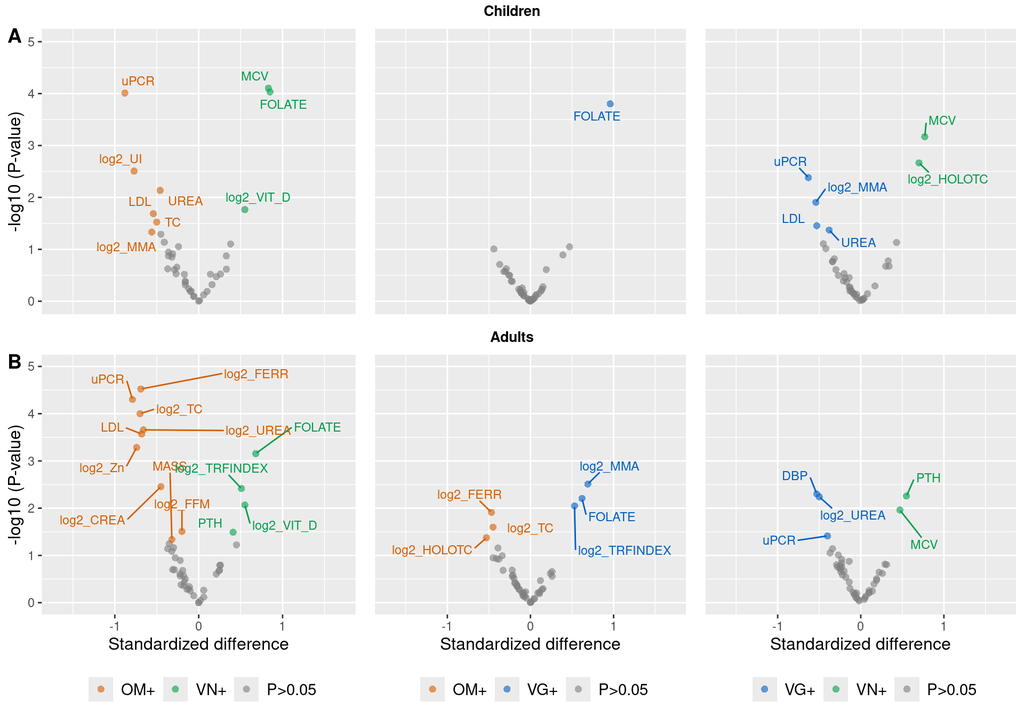

Vulcano plot showing standardized differences between vegan (VN) and omnivores (OM) (*left*), vegetarians (VG) vs OM (*middle*) and VN vs VG (*right*) across clinical outcomes in children (**A**, *top*) and adults (**B**, *bottom*). Estimated effects are based on linear mixed-effects models. P-values are not corrected for multiple comparisons to maximize sensitivity for a potential risks

```r
if(file.exists(path) == FALSE){
  assign(plotac,
       ggarrange(
         children_volc,
         adult_volc,
         nrow = 2,
         ncol = 1,
         heights = c(1, 1.2))
       )

  saveRDS(get(plotac), file = path)
  get(plotac)} else {
    assign(plotac, readRDS(path))
    get(plotac)}
```

**Open code**

```r
## save svg
plotac <- "fig35_nr"
path <- paste0("gitignore/figures/", plotac, ".svg")

if(!file.exists(path)){
  ggsave(path, get(plotac), device = 'svg', width = 10, height = 7)
}
```

# 4 Reproducibility

**Open code**

```r
sessionInfo()
## R version 4.4.3 (2025-02-28)
## Platform: x86_64-pc-linux-gnu
## Running under: Ubuntu 22.04.5 LTS
##
## Matrix products: default
## BLAS:   /usr/lib/x86_64-linux-gnu/blas/libblas.so.3.10.0
## LAPACK: /usr/lib/x86_64-linux-gnu/lapack/liblapack.so.3.10.0
##
## locale:
##  [1] LC_CTYPE=en_US.UTF-8       LC_NUMERIC=C
##  [3] LC_TIME=cs_CZ.UTF-8        LC_COLLATE=en_US.UTF-8
##  [5] LC_MONETARY=cs_CZ.UTF-8    LC_MESSAGES=en_US.UTF-8
##  [7] LC_PAPER=cs_CZ.UTF-8       LC_NAME=C
##  [9] LC_ADDRESS=C               LC_TELEPHONE=C
## [11] LC_MEASUREMENT=cs_CZ.UTF-8 LC_IDENTIFICATION=C
##
## time zone: Europe/Prague
## tzcode source: system (glibc)
##
## attached base packages:
## [1] grid      stats     graphics  grDevices utils     datasets  methods
## [8] base
##
## other attached packages:
##  [1] mice_3.17.0        patchwork_1.2.0    ggrepel_0.9.5      robustlmm_3.3-1
##  [5] gridExtra_2.3      pheatmap_1.0.12    performance_0.12.2 quantreg_5.98
##  [9] SparseM_1.81       bayesplot_1.8.1    ggdist_3.3.2       kableExtra_1.4.0
## [13] lubridate_1.8.0    corrplot_0.92      arm_1.12-2         MASS_7.3-65
## [17] projpred_2.0.2     glmnet_4.1-8       boot_1.3-31        cowplot_1.1.1
## [21] pROC_1.18.0        mgcv_1.9-1         nlme_3.1-168       openxlsx_4.2.8
## [25] flextable_0.9.6    sjPlot_2.8.16      car_3.1-2          carData_3.0-5
## [29] gtsummary_2.0.2    emmeans_1.10.4     ggpubr_0.4.0       lme4_1.1-35.5
## [33] Matrix_1.7-0       forcats_1.0.0      stringr_1.5.1      dplyr_1.1.4
## [37] purrr_1.0.2        readr_2.1.2        tidyr_1.3.1        tibble_3.2.1
## [41] ggplot2_3.5.1      tidyverse_1.3.1
##
## loaded via a namespace (and not attached):
##   [1] splines_4.4.3           later_1.3.0             gamm4_0.2-6
##   [4] cellranger_1.1.0        datawizard_0.12.2       rpart_4.1.24
##   [7] reprex_2.0.1            lifecycle_1.0.4         rstatix_0.7.0
##  [10] lattice_0.22-5          insight_0.20.2          backports_1.5.0
##  [13] magrittr_2.0.3          rmarkdown_2.27          yaml_2.3.5
##  [16] httpuv_1.6.5            zip_2.2.0               askpass_1.1
##  [19] DBI_1.1.2               minqa_1.2.4             RColorBrewer_1.1-2
##  [22] multcomp_1.4-18         abind_1.4-5             rvest_1.0.2
##  [25] nnet_7.3-20             TH.data_1.1-0           sandwich_3.0-1
##  [28] gdtools_0.3.7           crul_1.5.0              MatrixModels_0.5-3
##  [31] svglite_2.1.3           codetools_0.2-19        xml2_1.3.3
##  [34] tidyselect_1.2.1        shape_1.4.6             farver_2.1.0
##  [37] ggeffects_1.7.0         httpcode_0.3.0          matrixStats_1.3.0
##  [40] jsonlite_1.8.8          mitml_0.4-3             ellipsis_0.3.2
##  [43] ggridges_0.5.3          survival_3.7-0          iterators_1.0.14
##  [46] systemfonts_1.0.4       foreach_1.5.2           tools_4.4.3
##  [49] ragg_1.2.1              Rcpp_1.0.13             glue_1.7.0
##  [52] pan_1.6                 xfun_0.46               distributional_0.4.0
##  [55] loo_2.4.1               withr_3.0.1             fastmap_1.2.0
##  [58] fansi_1.0.6             openssl_1.4.6           digest_0.6.37
##  [61] R6_2.5.1                mime_0.12               estimability_1.5.1
##  [64] textshaping_0.3.6       colorspace_2.0-2        utf8_1.2.4
##  [67] generics_0.1.3          fontLiberation_0.1.0    data.table_1.15.4
##  [70] robustbase_0.93-9       httr_1.4.2              htmlwidgets_1.6.4
##  [73] pkgconfig_2.0.3         gtable_0.3.0            htmltools_0.5.8.1
##  [76] fontBitstreamVera_0.1.1 scales_1.3.0            knitr_1.48
##  [79] rstudioapi_0.16.0       tzdb_0.2.0              uuid_1.0-3
##  [82] coda_0.19-4             curl_4.3.2              nloptr_2.0.0
##  [85] zoo_1.8-9               sjlabelled_1.2.0        parallel_4.4.3
##  [88] pillar_1.9.0            vctrs_0.6.5             promises_1.2.0.1
##  [91] jomo_2.7-3              dbplyr_2.1.1            xtable_1.8-4
##  [94] evaluate_1.0.0          fastGHQuad_1.0.1        mvtnorm_1.1-3
##  [97] cli_3.6.3               compiler_4.4.3          rlang_1.1.4
## [100] crayon_1.5.0            rstantools_2.1.1        ggsignif_0.6.3
## [103] modelr_0.1.8            plyr_1.8.6              sjmisc_2.8.10
## [106] fs_1.6.4                stringi_1.7.6           viridisLite_0.4.0
## [109] assertthat_0.2.1        munsell_0.5.0           fontquiver_0.2.1
## [112] sjstats_0.19.0          hms_1.1.1               gfonts_0.2.0
## [115] shiny_1.9.1             highr_0.11              haven_2.4.3
## [118] broom_1.0.6             DEoptimR_1.0-10         readxl_1.3.1
## [121] officer_0.6.6
```